# Stage 06b: Genotyping results

Dataset: big - 24 barcodes

06 November 2026

This script uses a lot of different chunks to visualize different genotyping results from different methods. Its really kinda long, before every chunk is a quick description of what im trying to show with the plots and some ideas and questions I was trying to answer with the visualization. Plots are saved inside Results/dataset_name/Graphics/…

After completing this script, move on to Stage 06c: Speed optimisation

## 1 Settings, paths and basic setup

This chunks contain libraries, global settings, editable variables used by the whole .Rmd and paths for necessary input files.

```r
suppressMessages({
  library(grid)
  library(Biostrings) # loaded first because of shared functions names with dplyr
  library(ggplot2)
  library(dplyr)
  library(tidyr)
  library(readr)
  library(readxl)
  library(patchwork)
  library(scales)
  library(knitr)
  library(rstan)
  library(bayesplot)
})

# Settings come from the params block in the YAML header, this turns them into usable variables
invisible(list2env(params, envir = environment()))
settings_used <- data.frame(setting = c("run_date", names(params)),
                            value = c(format(Sys.time(), "%Y-%m-%d %H:%M"),
                                      vapply(params, function(setting_value) paste(setting_value, collapse = ", "), character(1))))
# Uploading shared functions
source("Code/R_scripts/asp_functions.R", local = TRUE)

plot_font <- "Times New Roman"
theme_set(theme_minimal(base_family = plot_font))
hm_dark <- "#476F84"
ht_dark <- "#A4552A"
correct_colour <- "#72874E" # correct calls, reads used
error_colour <- "#d73027" # miscalls, incorrect calls, removing cutoffs
no_call_colour <- "grey70"
no_reference_colour <- "grey97"
method_colours <- c(ASP = "#834D24", ASP_bayesian = "#834D24", minimap2 = "#E1C473")
group_colours <- c("All pairs" = "grey25", "True homozygotes" = hm_dark, "True heterozygotes" = ht_dark)
# Paths for genotype and graphics outputs
graphics_dir <- file.path("Results", dataset_name, "Graphics")
genotypes_dir <- file.path("Results", dataset_name, "Genotypes_results")

# Shared function for building accurate settings based folder names
run_names <- build_run_names(input_type, use_anchors, anchor_length, threshold_type, error_rate, min_score_fraction,
                             prior_type, prior_het_share, prior_population, prior_floor, probe_type = probe_type,
                             ancestry_prior_shape = ancestry_prior_shape, phi_hom_structure = phi_hom_structure)
asp_run_name <- run_names$asp_run_name
bayes_run_name <- run_names$bayes_run_name

asp_path <- file.path(genotypes_dir, asp_run_name, "all_barcodes_asp_genotypes.tsv") # ASP Genotyper results and per read calls
mm2_path <- file.path(genotypes_dir, "MiniMap2_genotypes/all_barcodes_Minimap2_genotypes.tsv") # MiniMap2 genotype results
bayes_path <- file.path(genotypes_dir, bayes_run_name, "all_barcodes_base_mixture_genotypes_hierarchical.tsv") # ASP Hierarchical Bayes Genotyper results
ref_path <- file.path("Data/Supporting_data/Reference_genotypes", paste0("genotypes_", dataset_name, ".tsv")) # Genotype references

# Primer panel preparation with a shared function and the same scoring lookups for scoring threshold, problematic locus and Sankey plots
panel <- prepare_primer_panel(primer_panel_path, reference_path, input_type, use_anchors, anchor_length, probe_type = probe_type)

# Output paths for Identified, Bayes and MiniMap2 plots
out_dir <- file.path(graphics_dir, "ASP_Genotypes_Results_Plots")
dir.create(out_dir, recursive = TRUE, showWarnings = FALSE)
bayes_run_graphics_dir <- file.path(graphics_dir, "STAN_Hierarchical", run_names$bayes_settings_label)
stan_graphics_folder <- bayes_run_graphics_dir # the same folder, under the name the Stan plot chunks use
read_depths_to_test <- unlist(read_depths_to_test)
downsampling_output_folder <- file.path(stan_graphics_folder, paste0("Downsampling_calibration", if (strand_downgrade) "_sdown" else "_sflag", sprintf("_r%d_d%d_n%d", minimum_reads_for_truth_pair, max(read_depths_to_test), draws_per_depth)))

bayes_out_dir <- file.path(bayes_run_graphics_dir, "Basic_Results_Plots")
dir.create(bayes_out_dir, recursive = TRUE, showWarnings = FALSE)
mm2_out_dir <- file.path(graphics_dir, "Minimap2_Genotypes_Results_Plots")
dir.create(mm2_out_dir, recursive = TRUE, showWarnings = FALSE)

# Imported shared data between all chunks, loaded and cleaned once in setup
asp_results <- read_tsv(asp_path, show_col_types = FALSE)
asp <- asp_results %>%
  transmute(sample = barcode, locus, genotype, method = "ASP")

bayes_raw <- read_tsv(bayes_path, show_col_types = FALSE)
bayes_asp <- bayes_raw %>%
  transmute(sample = barcode, locus, genotype, method = "ASP_bayesian", status)

mm2_raw <- read_tsv(mm2_path, show_col_types = FALSE)
mm2 <- mm2_raw %>%
  transmute(sample = barcode, locus, genotype, method = "minimap2")

ref <- read_tsv(ref_path, show_col_types = FALSE) %>%
  transmute(sample = sample_id, locus, genotype, method = "reference")
```

## 2 Basic visualization for ASP genotypes results

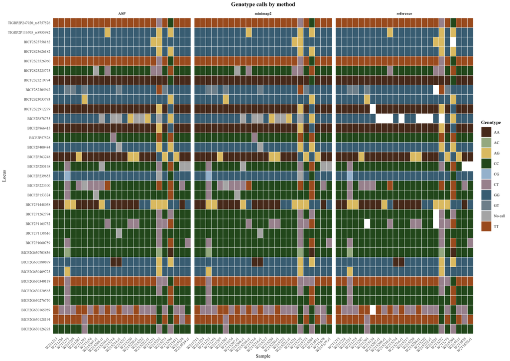

```r
# Full data frame with all the genotypes
all_calls <- bind_rows(asp, mm2, ref)

# Comparison table sample and locus pairs per row and a match column per method
wide <- all_calls %>%
  pivot_wider(names_from = method, values_from = genotype) %>%
  complete(sample, locus) %>%
  mutate(asp_match = ASP == reference, # T or F, NA if one is missing
         mm2_match = minimap2 == reference,
         methods_agree = ASP == minimap2)

write.table(wide, file.path(out_dir, "full_comparison_table_identified.tsv"), sep = "\t", row.names = FALSE, quote = FALSE)

# 1. Plot: Creates called genotypes heatmap per method
genotype_colours <- c(
  "AA" = "#593722",
  "CC" = "#2C5724",
  "GG" = "#476F84",
  "TT" = "#AB5D26",
  "AC" = "#A4B591",
  "AG" = "#E1C473",
  "AT" = "#D9A877",
  "CG" = "#A4BED5",
  "CT" = "#A8939E",
  "GT" = "#7F919B",
  "No call" = no_call_colour)

plot_data <- all_calls %>%
  mutate(genotype_display = ifelse(is.na(genotype), "No call", genotype))

p1 <- ggplot(plot_data, aes(x = sample, y = locus, fill = genotype_display)) +
  geom_tile(colour = "white", linewidth = 0.2) +
  facet_wrap(~method, ncol = 3) + # Splits into 3 panels
  scale_fill_manual(values = genotype_colours, name = "Genotype") +
  labs(title = "Genotype calls by method", x = "Sample", y = "Locus") +
  theme_minimal(base_family = plot_font, base_size = 8) +
  theme(plot.title = element_text(face = "bold", hjust = 0.5),
        legend.title = element_text(face = "bold"),
        strip.text = element_text(face = "bold"),
        axis.text.x = element_text(angle = 45, hjust = 1),
        axis.text.y = element_text(size = 6),
        panel.grid = element_blank())

ggsave(file.path(out_dir, "genotype_heatmap_by_method.png"), p1,
       width = 14, height = max(6, length(unique(plot_data$locus)) * 0.15 + 2), dpi = 300, limitsize = FALSE, bg = "white")
ggsave(file.path(out_dir, "genotype_heatmap_by_method.pdf"), p1,
       width = 14, height = max(6, length(unique(plot_data$locus)) * 0.15 + 2), limitsize = FALSE, device = cairo_pdf)
print(p1)
```

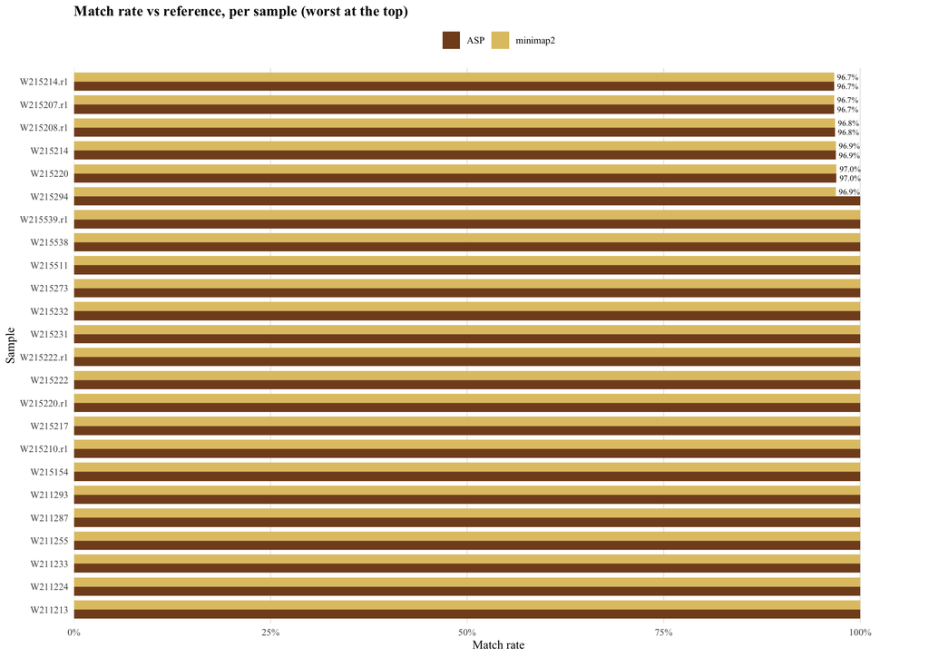

```r
# 2. Plot: Genotype match rate per sample
per_sample <- wide %>%
  filter(!is.na(reference)) %>%
  group_by(sample) %>%
  summarise(
    ASP = mean(asp_match, na.rm = TRUE),
    minimap2 = mean(mm2_match, na.rm = TRUE)) %>%
  pivot_longer(cols = c(ASP, minimap2), names_to = "method", values_to = "match_rate")

p2 <- ggplot(per_sample, aes(x = match_rate, y = reorder(sample, -match_rate), fill = method)) +
  geom_col(position = position_dodge(width = 0.8), width = 0.8) +
  geom_text(aes(label = ifelse(match_rate < 1, percent(match_rate, accuracy = 0.1), "")),
            position = position_dodge(width = 0.8), hjust = -0.15, size = 2.6) +
  scale_fill_manual(values = method_colours, name = NULL) +
  scale_x_continuous(labels = percent, expand = expansion(mult = c(0, 0.08))) +
  labs(title = "Match rate vs reference, per sample (worst at the top)", x = "Match rate", y = "Sample") +
  theme_minimal(base_family = plot_font, base_size = 11) +
  theme(plot.title = element_text(face = "bold"), legend.position = "top",
        panel.grid.major.y = element_blank(), panel.grid.minor = element_blank())

ggsave(file.path(out_dir, "concordance_per_sample.png"), p2, width = 8.27, height = 11.69, dpi = 300, bg = "white")
ggsave(file.path(out_dir, "concordance_per_sample.pdf"), p2, width = 8.27, height = 11.69, device = cairo_pdf)
print(p2)
```

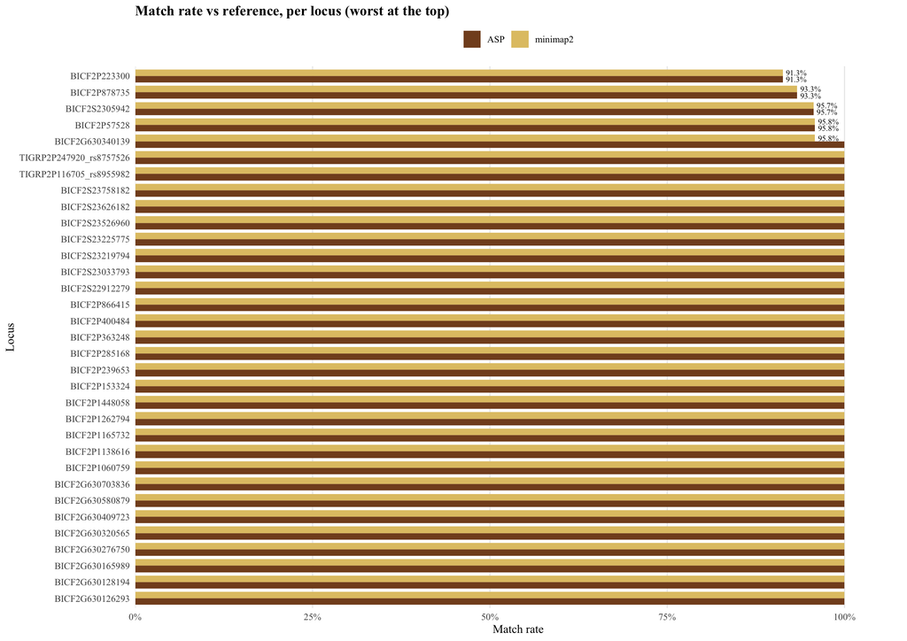

```r
# 3. Plot: Result concordance per locus
per_locus <- wide %>%
  filter(!is.na(reference)) %>%
  group_by(locus) %>%
  summarise(
    ASP = mean(asp_match, na.rm = TRUE),
    minimap2 = mean(mm2_match, na.rm = TRUE)) %>%
  pivot_longer(cols = c(ASP, minimap2), names_to = "method", values_to = "match_rate")

# Average for both method, worst first
locus_avg <- per_locus %>%
  group_by(locus) %>%
  summarise(avg_match = mean(match_rate, na.rm = TRUE)) %>%
  arrange(avg_match)

p3 <- ggplot(per_locus, aes(x = match_rate, y = reorder(locus, -match_rate), fill = method)) +
  geom_col(position = position_dodge(width = 0.8), width = 0.8) +
  geom_text(aes(label = ifelse(match_rate < 1, percent(match_rate, accuracy = 0.1), "")),
            position = position_dodge(width = 0.8), hjust = -0.15, size = 2.6) +
  scale_fill_manual(values = method_colours, name = NULL) +
  scale_x_continuous(labels = percent, expand = expansion(mult = c(0, 0.08))) +
  labs(title = "Match rate vs reference, per locus (worst at the top)", x = "Match rate", y = "Locus") +
  theme_minimal(base_family = plot_font, base_size = 11) +
  theme(plot.title = element_text(face = "bold"), legend.position = "top",
        panel.grid.major.y = element_blank(), panel.grid.minor = element_blank())

ggsave(file.path(out_dir, "concordance_per_locus.png"), p3, width = 8.27, height = 11.69, dpi = 300, bg = "white")
ggsave(file.path(out_dir, "concordance_per_locus.pdf"), p3, width = 8.27, height = 11.69, device = cairo_pdf)
print(p3)
```

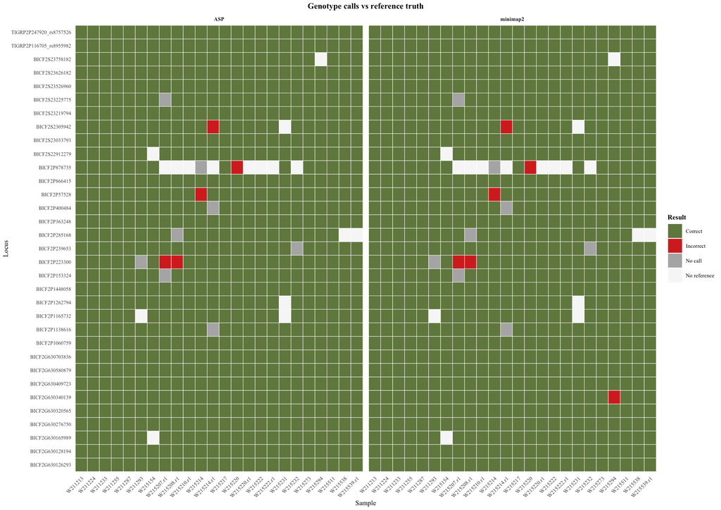

```r
# 4. Plot: Same as first heatmap just simpler with only red and green values for correct and incorrect called genotypes
match_data <- wide %>%
  select(sample, locus, reference, ASP = asp_match, minimap2 = mm2_match) %>%
  pivot_longer(cols = c(ASP, minimap2), names_to = "method", values_to = "is_match") %>%
  mutate(
    match_category = case_when(
      is.na(reference) ~ "No reference",
      is.na(is_match) ~ "No call",
      is_match ~ "Correct",
      TRUE ~ "Incorrect"))

p4 <- ggplot(match_data, aes(x = sample, y = locus, fill = match_category)) +
  geom_tile(colour = "white", linewidth = 0.2) +
  facet_wrap(~method, ncol = 2) +
  scale_fill_manual(
    values = c("Correct" = correct_colour, "Incorrect" = error_colour,
               "No call" = no_call_colour, "No reference" = no_reference_colour),
    name = "Result") +
  labs(title = "Genotype calls vs reference truth", x = "Sample", y = "Locus") +
  theme_minimal(base_family = plot_font, base_size = 8) +
  theme(plot.title = element_text(face = "bold", hjust = 0.5),
        legend.title = element_text(face = "bold"),
        strip.text = element_text(face = "bold"),
        axis.text.x = element_text(angle = 45, hjust = 1),
        axis.text.y = element_text(size = 6),
        panel.grid = element_blank())

ggsave(file.path(out_dir, "genotype_match_heatmap.png"), p4, width = max(9, length(unique(match_data$sample)) * 0.5 + 3),
       height = max(6, length(unique(match_data$locus)) * 0.15 + 2), dpi = 300, limitsize = FALSE, bg = "white")
ggsave(file.path(out_dir, "genotype_match_heatmap.pdf"), p4, width = max(9, length(unique(match_data$sample)) * 0.5 + 3),
       height = max(6, length(unique(match_data$locus)) * 0.15 + 2), limitsize = FALSE, device = cairo_pdf)
print(p4)
```

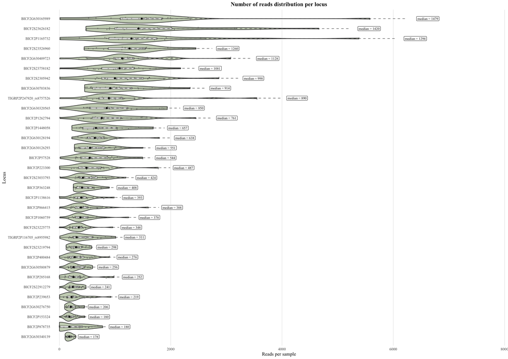

```r
# 5. Plot: Depth per locus and locus family in violin plots
depth_family_pattern <- "^(BICF2P|BICF2S|BICF2G|TIGRP2P)"

# Creates locus families from the names prefix
depth_data <- asp_results %>%
  transmute(sample = barcode, locus, depth,
            locus_group = ifelse(grepl(depth_family_pattern, locus), sub(paste0(depth_family_pattern, ".*"), "\\1", locus), "Other"))

depth_fills <- c("all" = "#A4B591", "BICF2P" = "#AB5D26", "BICF2S" = "#E1C473", "BICF2G" = "#55804D", "TIGRP2P" = "#593722", "Other" = "grey70")

# One violin plot per row
depth_violin_f <- function(data, title, x_label, y_label) {
  medians <- data %>%
    group_by(row) %>%
    summarise(median_depth = median(depth, na.rm = TRUE), max_depth = max(depth, na.rm = TRUE))

  ggplot(data, aes(x = depth, y = row)) +
    geom_violin(aes(fill = fill_group), colour = "grey20", linewidth = 0.4, alpha = 0.6, scale = "width") +
    geom_boxplot(width = 0.15, fill = "white", colour = "grey30", outlier.shape = NA, linewidth = 0.3) +
    geom_jitter(height = 0.12, width = 0, size = 0.5, alpha = 0.35, colour = "grey30") +
    geom_point(data = medians, aes(x = median_depth, y = row), colour = "grey10", size = 1.2, inherit.aes = FALSE) +
    geom_segment(data = medians, aes(x = median_depth, xend = max_depth * 1.12, y = row, yend = row),
                 linetype = "dashed", colour = "grey30", linewidth = 0.3, inherit.aes = FALSE) +
    geom_label(data = medians, aes(x = max_depth * 1.15, y = row, label = sprintf("median = %.0f", median_depth)),
               hjust = 0, size = 2, fill = "white", linewidth = 0.2, inherit.aes = FALSE) +
    scale_fill_manual(values = depth_fills, name = "Locus\ngroup",
                      guide = if (n_distinct(data$fill_group) > 1) "legend" else "none") + # legend only when coloured by family
    scale_x_continuous(expand = expansion(mult = c(0.02, 0.25))) +
    scale_y_discrete(expand = expansion(add = 0.9)) + # space between the rows
    theme_minimal(base_family = plot_font, base_size = 8) +
    theme(axis.text.y = element_text(size = 6),
          panel.grid.minor = element_blank(),
          panel.grid.major.y = element_blank(),
          plot.title = element_text(hjust = 0.5, face = "bold")) +
    labs(title = title, x = x_label, y = y_label)
}

# Depth per locus ordered by median depth, violin plots
depth_plot_locus <- depth_violin_f(depth_data %>% mutate(row = reorder(locus, depth, FUN = median, na.rm = TRUE), fill_group = "all"), "Number of reads distribution per locus", "Reads per sample", "Locus")
print(depth_plot_locus)
```

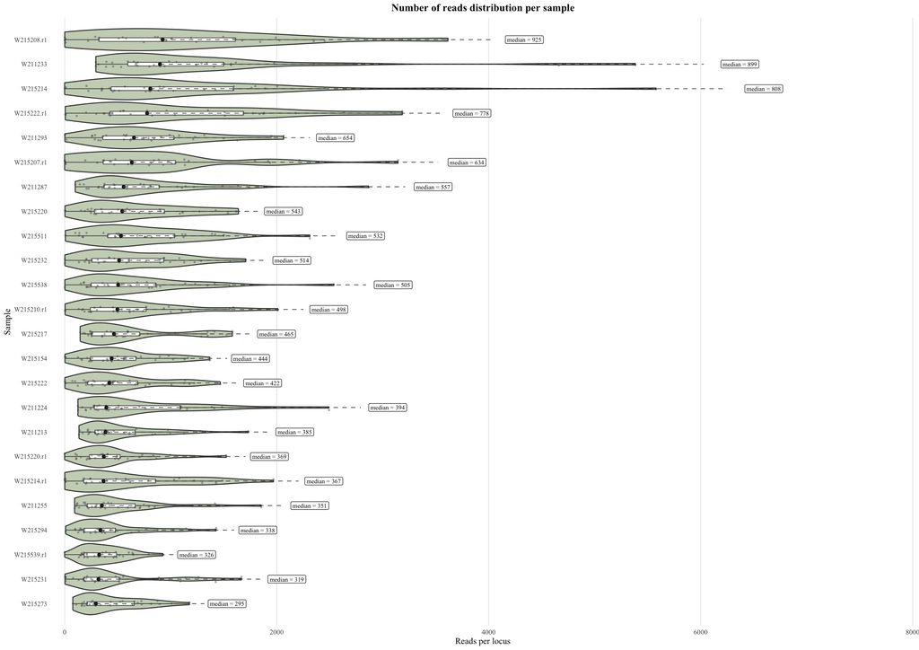

```r
ggsave(file.path(out_dir, "read_distribution_per_locus_violin.png"), depth_plot_locus, width = 8.27, height = 11.69, dpi = 300, bg = "white")
ggsave(file.path(out_dir, "read_distribution_per_locus_violin.pdf"), depth_plot_locus, width = 8.27, height = 11.69, device = cairo_pdf)

# 6. Plot: Depth per sample ordered by median depth, violin plots
depth_plot_sample <- depth_violin_f(depth_data %>% mutate(row = reorder(sample, depth, FUN = median, na.rm = TRUE), fill_group = "all"), "Number of reads distribution per sample", "Reads per locus", "Sample")
print(depth_plot_sample)
```

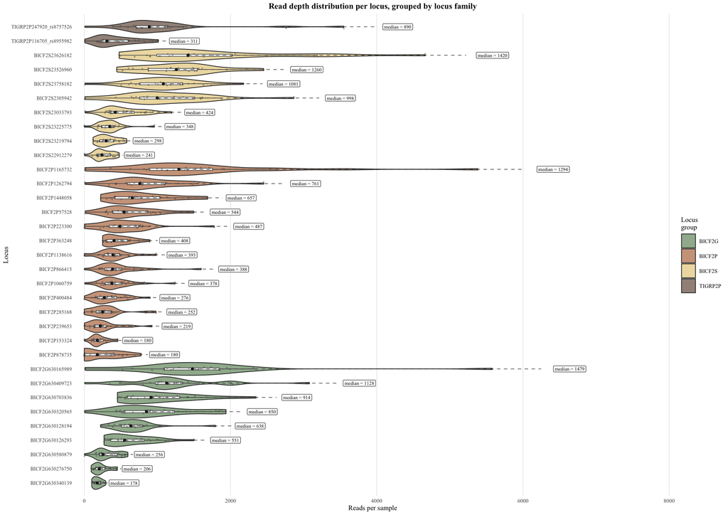

```r
ggsave(file.path(out_dir, "read_distribution_per_sample_violin.png"), depth_plot_sample, width = 8.27, height = 11.69, dpi = 300, bg = "white")
ggsave(file.path(out_dir, "read_distribution_per_sample_violin.pdf"), depth_plot_sample, width = 8.27, height = 11.69, device = cairo_pdf)

# 7. Plot: Depth per locus family ordered in groups by median depth, violin plots
depth_grouped_order <- depth_data %>%
  group_by(locus_group, locus) %>%
  summarise(median_depth = median(depth, na.rm = TRUE), .groups = "drop") %>%
  arrange(locus_group, median_depth) %>%
  pull(locus)

depth_plot_grouped <- depth_violin_f(depth_data %>% mutate(row = factor(locus, levels = depth_grouped_order), fill_group = locus_group), "Read depth distribution per locus, grouped by locus family", "Reads per sample", "Locus")
print(depth_plot_grouped)
```

```r
ggsave(file.path(out_dir, "read_depth_per_locus_grouped_violin.png"), depth_plot_grouped, width = 8.27, height = 11.69, dpi = 300, bg = "white")
ggsave(file.path(out_dir, "read_depth_per_locus_grouped_violin.pdf"), depth_plot_grouped, width = 8.27, height = 11.69, device = cairo_pdf)
```

## 3 Hierarchical bayes base mixture type

This chunk contains the same first version of visualizations created for hierarchical Bayes model, same plots as the previous chunk just changed input paths and output paths for Bayes.

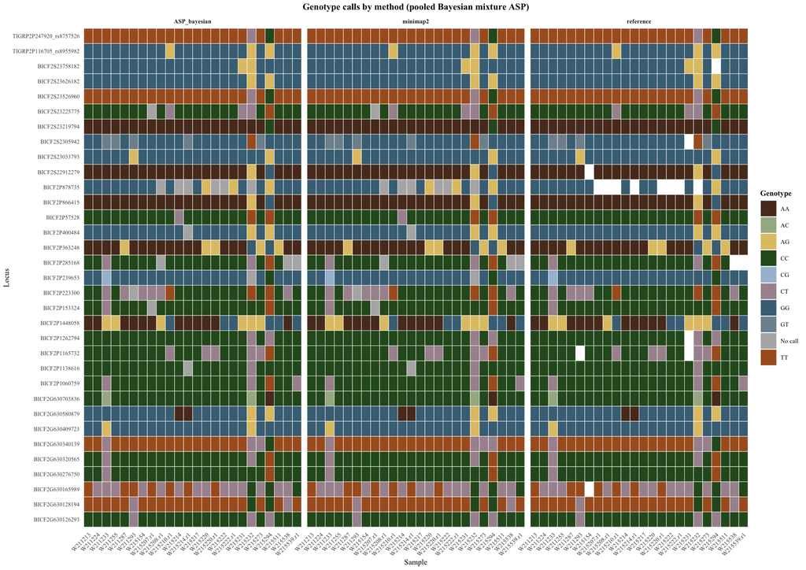

```r
# Same chunks before it just uses Bayesian Genotypes results tables imported and cleaned in the setup chunk
bayes_all_calls <- bind_rows(select(bayes_asp, -status), mm2, ref)

# Comparison table sample and locus pairs per row and a match column per method
bayes_wide <- bayes_all_calls %>%
  pivot_wider(names_from = method, values_from = genotype) %>%
  complete(sample, locus) %>%
  mutate(asp_match = ASP_bayesian == reference, # T or F, NA if one is missing
         mm2_match = minimap2 == reference)

write.table(bayes_wide, file.path(bayes_out_dir, "full_comparison_table_bayesian_mixpooled.tsv"), sep = "\t", row.names = FALSE, quote = FALSE)

# 1. Plot: Creates called genotypes heatmap per method
bayes_plot_data <- bayes_all_calls %>%
  mutate(genotype_display = ifelse(is.na(genotype), "No call", genotype))

p_bayes_genotypes <- ggplot(bayes_plot_data, aes(x = sample, y = locus, fill = genotype_display)) +
  geom_tile(colour = "white", linewidth = 0.2) +
  facet_wrap(~method, ncol = 3) +
  scale_fill_manual(values = genotype_colours, name = "Genotype") +
  labs(title = "Genotype calls by method (pooled Bayesian mixture ASP)", x = "Sample", y = "Locus") +
  theme_minimal(base_family = plot_font, base_size = 8) +
  theme(plot.title = element_text(face = "bold", hjust = 0.5),
        legend.title = element_text(face = "bold"),
        strip.text = element_text(face = "bold"),
        axis.text.x = element_text(angle = 45, hjust = 1),
        axis.text.y = element_text(size = 6),
        panel.grid = element_blank())

ggsave(file.path(bayes_out_dir, "genotype_heatmap_by_method_bayesian_mixpooled.png"), p_bayes_genotypes,
       width = max(14, length(unique(bayes_plot_data$sample)) * 0.5 + 4),
       height = max(6, length(unique(bayes_plot_data$locus)) * 0.15 + 2), dpi = 300, limitsize = FALSE, bg = "white")
ggsave(file.path(bayes_out_dir, "genotype_heatmap_by_method_bayesian_mixpooled.pdf"), p_bayes_genotypes,
       width = max(14, length(unique(bayes_plot_data$sample)) * 0.5 + 4),
       height = max(6, length(unique(bayes_plot_data$locus)) * 0.15 + 2), limitsize = FALSE, device = cairo_pdf)
p_bayes_genotypes
```

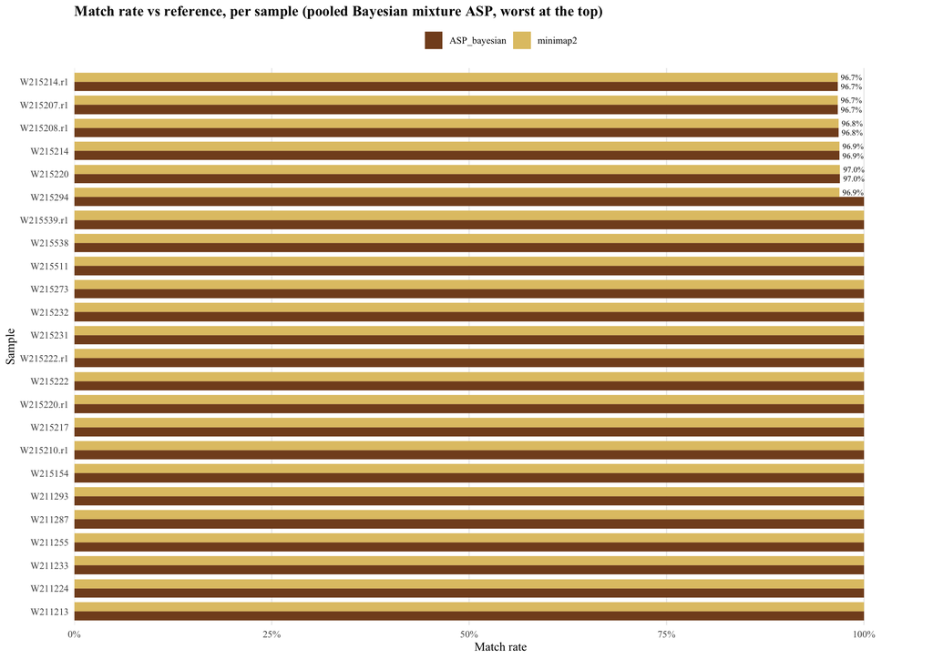

```r
# 2. Plot: Genotype match rate per sample
bayes_per_sample <- bayes_wide %>%
  filter(!is.na(reference)) %>%
  group_by(sample) %>%
  summarise(
    ASP_bayesian = mean(asp_match, na.rm = TRUE),
    minimap2 = mean(mm2_match, na.rm = TRUE)) %>%
  pivot_longer(cols = c(ASP_bayesian, minimap2), names_to = "method", values_to = "match_rate")

p_bayes_per_sample <- ggplot(bayes_per_sample, aes(x = match_rate, y = reorder(sample, -match_rate), fill = method)) +
  geom_col(position = position_dodge(width = 0.8), width = 0.8) +
  geom_text(aes(label = ifelse(match_rate < 1, percent(match_rate, accuracy = 0.1), "")),
            position = position_dodge(width = 0.8), hjust = -0.15, size = 2.6) +
  scale_fill_manual(values = method_colours, name = NULL) +
  scale_x_continuous(labels = percent, expand = expansion(mult = c(0, 0.08))) +
  labs(title = "Match rate vs reference, per sample (pooled Bayesian mixture ASP, worst at the top)", x = "Match rate", y = "Sample") +
  theme_minimal(base_family = plot_font, base_size = 11) +
  theme(plot.title = element_text(face = "bold"), legend.position = "top",
        panel.grid.major.y = element_blank(), panel.grid.minor = element_blank())

ggsave(file.path(bayes_out_dir, "concordance_per_sample_bayesian_mixpooled.png"), p_bayes_per_sample, width = 8.27, height = 11.69, dpi = 300, bg = "white")
ggsave(file.path(bayes_out_dir, "concordance_per_sample_bayesian_mixpooled.pdf"), p_bayes_per_sample, width = 8.27, height = 11.69, device = cairo_pdf)
print(p_bayes_per_sample)
```

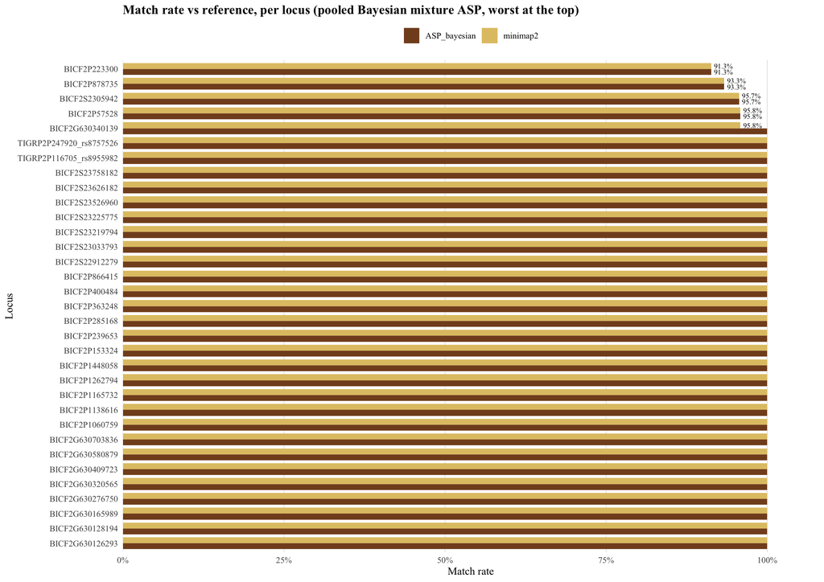

```r
# 3. Plot: Result concordance per locus
bayes_per_locus <- bayes_wide %>%
  filter(!is.na(reference)) %>%
  group_by(locus) %>%
  summarise(
    ASP_bayesian = mean(asp_match, na.rm = TRUE),
    minimap2 = mean(mm2_match, na.rm = TRUE)) %>%
  pivot_longer(cols = c(ASP_bayesian, minimap2), names_to = "method", values_to = "match_rate")

bayes_locus_avg <- bayes_per_locus %>% # average of both methods per locus, worst first
  group_by(locus) %>%
  summarise(avg_match = mean(match_rate, na.rm = TRUE)) %>%
  arrange(avg_match)

p_bayes_per_locus <- ggplot(bayes_per_locus, aes(x = match_rate, y = reorder(locus, -match_rate), fill = method)) +
  geom_col(position = position_dodge(width = 0.8), width = 0.8) +
  geom_text(aes(label = ifelse(match_rate < 1, percent(match_rate, accuracy = 0.1), "")),
            position = position_dodge(width = 0.8), hjust = -0.15, size = 2.6) +
  scale_fill_manual(values = method_colours, name = NULL) +
  scale_x_continuous(labels = percent, expand = expansion(mult = c(0, 0.08))) +
  labs(title = "Match rate vs reference, per locus (pooled Bayesian mixture ASP, worst at the top)", x = "Match rate", y = "Locus") +
  theme_minimal(base_family = plot_font, base_size = 11) +
  theme(plot.title = element_text(face = "bold"), legend.position = "top",
        panel.grid.major.y = element_blank(), panel.grid.minor = element_blank())

ggsave(file.path(bayes_out_dir, "concordance_per_locus_bayesian_mixpooled.png"), p_bayes_per_locus, width = 8.27, height = 11.69, dpi = 300, bg = "white")
ggsave(file.path(bayes_out_dir, "concordance_per_locus_bayesian_mixpooled.pdf"), p_bayes_per_locus, width = 8.27, height = 11.69, device = cairo_pdf)
print(p_bayes_per_locus)
```

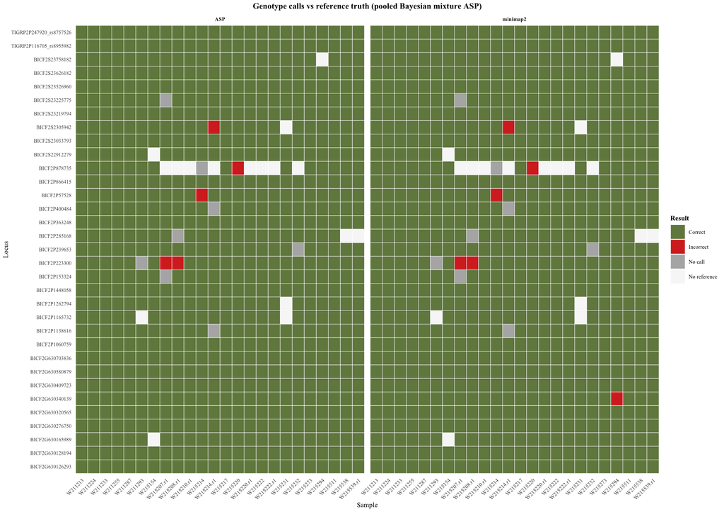

```r
# 4. Plot: Same as first heatmap just simpler with only red and green values for correct and incorrect called genotypes
bayes_match_data <- bayes_wide %>%
  select(sample, locus, reference, ASP = asp_match, minimap2 = mm2_match) %>%
  pivot_longer(cols = c(ASP, minimap2), names_to = "method", values_to = "is_match") %>%
  mutate(
    match_category = case_when(
      is.na(reference) ~ "No reference",
      is.na(is_match) ~ "No call",
      is_match ~ "Correct",
      TRUE ~ "Incorrect"))

p_bayes_match <- ggplot(bayes_match_data, aes(x = sample, y = locus, fill = match_category)) +
  geom_tile(colour = "white", linewidth = 0.2) +
  facet_wrap(~method, ncol = 2) +
  scale_fill_manual(
    values = c("Correct" = correct_colour, "Incorrect" = error_colour, "No call" = no_call_colour, "No reference" = no_reference_colour),
    name = "Result") +
  labs(title = "Genotype calls vs reference truth (pooled Bayesian mixture ASP)", x = "Sample", y = "Locus") +
  theme_minimal(base_family = plot_font, base_size = 8) +
  theme(plot.title = element_text(face = "bold", hjust = 0.5),
        legend.title = element_text(face = "bold"),
        strip.text = element_text(face = "bold"),
        axis.text.x = element_text(angle = 45, hjust = 1),
        axis.text.y = element_text(size = 6),
        panel.grid = element_blank())

ggsave(file.path(bayes_out_dir, "genotype_match_heatmap_bayesian_mixpooled.png"), p_bayes_match,
       width = max(9, length(unique(bayes_match_data$sample)) * 0.5 + 3),
       height = max(6, length(unique(bayes_match_data$locus)) * 0.15 + 2), dpi = 300, limitsize = FALSE, bg = "white")
ggsave(file.path(bayes_out_dir, "genotype_match_heatmap_bayesian_mixpooled.pdf"), p_bayes_match,
       width = max(9, length(unique(bayes_match_data$sample)) * 0.5 + 3),
       height = max(6, length(unique(bayes_match_data$locus)) * 0.15 + 2), limitsize = FALSE, device = cairo_pdf)
print(p_bayes_match)
```

## 4 HWE Ternary Plots for ASP and Bayes Genotypes

```r
# Uses data frames which were prepared in the setup chunk
hwe_ternary_dir <- file.path(graphics_dir, "HWE_Ternary_plots")
dir.create(hwe_ternary_dir, recursive = TRUE, showWarnings = FALSE)

# Skips loci with too few called samples (safety check with smaller datasets)
min_samples_per_locus <- 4
hwe_methods <- c("reference", "ASP", "ASP_bayesian")

# Deviation from HWE was tested with the exact test (Wigginton et al., 2005), p value is the sum of all outcomes that are as likely or less likely than the observed one. This function takes a number of HT majors and minors and number of HT for one specific locus across all samples and it checks wether these countswould look like randommating (is in HW equilibrium) or not (other factors).
hwe_exact_p <- function(n_hom_major, n_het, n_hom_minor) {
  n <- n_hom_major + n_het + n_hom_minor # Calculates number of samples
  n_minor <- 2 * min(n_hom_major, n_hom_minor) + n_het # Calculates number of minor alleles
  het_possible <- seq(n_minor %% 2, n_minor, by = 2) # Exact test asks keeps the minor alleles and asks in how many different ways could they split into genotypes
  log_prob <- vapply(het_possible, function(het) { # Vapply takes each possible HT split and applies it to the function. This gives the probability of getting each split if alleles were mixed randomly (HWE)
    hom_minor <- (n_minor - het) / 2 # Calculates other HM minor and major based on the number of HT split
    hom_major <- n - het - hom_minor
    # Probability calculations turned into log for ease of. use with "+" and "-" ("P(counts|allele counts) = n!/(n_AA!*n_AB!*n_BB!)*2^n_AB*n_A!*n_B!/(2n)!")
    lfactorial(n) - lfactorial(hom_major) - lfactorial(het) - lfactorial(hom_minor) + het * log(2) +
      lfactorial(n_minor) + lfactorial(2 * n - n_minor) - lfactorial(2 * n)
  }, numeric(1))
  prob <- exp(log_prob) # Turned back to normal probability
  observed_prob <- prob[het_possible == n_het] # Takes the probability of that split if the popualtion were in HWE
  min(1, sum(prob[prob <= observed_prob * (1 + 1e-7)])) # p-value is the sum of all splits probabilites which are even less likely or as likely
}

# All called genotypes fo the three methods, filtered for loci with enough samples
hwe_calls <- bind_rows(ref, asp, select(bayes_asp, -status)) %>%
  filter(!is.na(genotype)) %>%
  group_by(method, locus) %>%
  filter(n() >= min_samples_per_locus) %>%
  ungroup()

# Counts allele copies per method and locus
hwe_allele_counts <- hwe_calls %>%
  mutate(allele_1 = substr(genotype, 1, 1), allele_2 = substr(genotype, 2, 2)) %>%
  pivot_longer(c(allele_1, allele_2), values_to = "allele") %>%
  count(method, locus, allele)

# Loci with moren than 2 different alleles are erros, they are left out in further analysis
hwe_too_many_alleles <- hwe_allele_counts %>% count(method, locus, name = "n_alleles") %>% filter(n_alleles > 2)
if (nrow(hwe_too_many_alleles) > 0) print(hwe_too_many_alleles)

# Major and minor alleles per method and locus
hwe_alleles <- hwe_allele_counts %>%
  group_by(method, locus) %>%
  filter(n() == 2) %>%
  arrange(desc(n), allele, .by_group = TRUE) %>%
  summarise(major = allele[1], minor = allele[2], .groups = "drop")

#Genotype counts per method and locus and applied exact test with HWE statistics
hwe_counts <- hwe_calls %>%
  inner_join(hwe_alleles, by = c("method", "locus")) %>%
  group_by(method, locus) %>%
  summarise(n = n(),
            n_hom_major = sum(genotype == paste0(major, major)),
            n_het = sum(genotype %in% c(paste0(major, minor), paste0(minor, major))),
            n_hom_minor = sum(genotype == paste0(minor, minor)),
            .groups = "drop") %>%
  group_by(locus) %>%
  filter(n_distinct(method) == length(hwe_methods)) %>% # Filter for same loci across methods so its comparable
  ungroup() %>%
  mutate(major_freq = (2 * n_hom_major + n_het) / (2 * n),
         he = 2 * major_freq * (1 - major_freq), # HWE expected HT
         ho = n_het / n, # HT observed
         f = 1 - ho / he, # Inbreeding coeeficient, if its > 0 to few HT, < 0 too many HT
         hwe_p = mapply(hwe_exact_p, n_hom_major, n_het, n_hom_minor), # Applies previously defined exact test function
         hwe_result = case_when(hwe_p >= 0.05 ~ "In HWE",
                                ho < he ~ "Heterozygote deficit (p < 0.05)",
                                TRUE ~ "Heterozygote excess (p < 0.05)"),
         method = factor(method, levels = hwe_methods))

# 1. Plot: Genotype posterior ternary plot for Bayes only
ternary_called <- filter(bayes_raw, status == "called")
ternary_confidence <- cut(ternary_called$max_posterior, breaks = c(-Inf, 0.80, 0.95, Inf), right = FALSE,
                          labels = c("uncertain (<0.80)", "intermediate (0.80-0.95)", "high (>=0.95)"))
ternary_colours <- c("uncertain (<0.80)" = error_colour, "intermediate (0.80-0.95)" = "#D9B44A", "high (>=0.95)" = correct_colour)

# Calcualates positions for each locus in the triangle (HT at the top, HM1 at x = 0 y = 0, and HM2 at x = 1, y = 0)
tern_x <- function(ab, bb) bb + ab / 2 # MAF
tern_y <- function(ab) ab * sqrt(3) / 2

# Grid lines at 25, 50 and 75 % of each genotype
ternary_shares <- c(0.25, 0.5, 0.75)
ternary_grid <- bind_rows(
  tibble(x = tern_x(ternary_shares, 0), y = tern_y(ternary_shares), xend = tern_x(ternary_shares, 1 - ternary_shares), yend = tern_y(ternary_shares)), # HT share
  tibble(x = tern_x(0, ternary_shares), y = 0, xend = tern_x(1 - ternary_shares, ternary_shares), yend = tern_y(1 - ternary_shares)), # HM2 share
  tibble(x = tern_x(0, 1 - ternary_shares), y = 0, xend = tern_x(1 - ternary_shares, 0), yend = tern_y(1 - ternary_shares))) # HM1 share

p_ternary_posterior <- ggplot(mutate(ternary_called, confidence = ternary_confidence),
                              aes(x = tern_x(posterior_het, posterior_hom2), y = tern_y(posterior_het), colour = confidence)) +
  geom_segment(data = ternary_grid, aes(x = x, y = y, xend = xend, yend = yend), colour = "grey90", inherit.aes = FALSE) +
  annotate("polygon", x = c(0, 1, 0.5), y = c(0, 0, sqrt(3) / 2), fill = NA, colour = "grey60") +
  annotate("text", x = c(0, 1, 0.5), y = c(-0.04, -0.04, sqrt(3) / 2 + 0.04), label = c("hom1", "hom2", "het")) +
  geom_point(size = 1.6) +
  scale_colour_manual(values = ternary_colours, breaks = rev(names(ternary_colours)), name = NULL) +
  coord_equal(xlim = c(-0.08, 1.08), ylim = c(-0.08, 0.95), expand = FALSE) +
  labs(title = sprintf("Genotype posterior ternary plot - hierarchical base mixture (n=%d)", nrow(ternary_called))) +
  theme_void(base_family = plot_font, base_size = 11) +
  theme(plot.title = element_text(hjust = 0.5, size = 10, face = "bold"), legend.position = "bottom",
        plot.background = element_rect(fill = "white", colour = NA))
```

```r
#print(p_ternary_posterior)
#ggsave(file.path(hwe_ternary_dir, "ternary_posterior_bayesian.png"), p_ternary_posterior, width = 7, height = 6.5, dpi = 300, bg = "white")
#ggsave(file.path(hwe_ternary_dir, "ternary_posterior_bayesian.pdf"), p_ternary_posterior, width = 7, height = 6.5, device = cairo_pdf)

# 2. Plot: HWE ternary plot by locus, each observed locus moves away from its reference genotypes, the difference is presented with arrows. MAF is along the base, AA is awlays the major one, so only half the traingle is needed

tern_n <- median(hwe_counts$n) # typical number of called samples per locus
tern_n_loci <- n_distinct(hwe_counts$locus)

#small tibble for each curve described by F (inbreeding coeficcient)
tern_edges <- tibble(edge = c("hwe", "nominal_low", "nominal_high", "bonferroni_low", "bonferroni_high"), # chi-square HWE test accepts |F| below the limit
                     f = c(0, 1, -1, 1, -1) * sqrt(qchisq(1 - 0.05 / c(1, 1, 1, tern_n_loci, tern_n_loci), df = 1) / tern_n))

tern_curves <- expand_grid(p = seq(0.5, 1, by = 0.001), tern_edges) %>%
  mutate(ab = 2 * p * (1 - p) * (1 - f),
         aa = p - ab / 2,
         bb = 1 - p - ab / 2) %>%
  filter(aa >= 0, bb >= 0) %>%
  mutate(x = tern_x(ab, bb), y = tern_y(ab))
tern_band <- bind_rows(filter(tern_curves, edge == "nominal_high") %>% arrange(p), # 95 % band polygon
                       filter(tern_curves, edge == "nominal_low") %>% arrange(desc(p)))

# Left half of the triangle
tern_half <- tibble(x = c(0, 0.5, 0.5), y = c(0, 0, sqrt(3) / 2))

# Lines for equal HT share
tern_het_lines <- tibble(het = c(0.25, 0.5, 0.75)) %>%
  mutate(x = het / 2, y = tern_y(het))
tern_maf_ticks <- tibble(x = seq(0, 0.5, by = 0.1))


tern_curve_labels <- tern_edges %>%
  filter(edge %in% c("hwe", "nominal_high", "bonferroni_high")) %>%
  mutate(x = 0.46, # MAF where the arrows point, just inside the right side
         y = tern_y(2 * 0.54 * 0.46 * (1 - f)),
         label = c("Hardy-Weinberg\nequilibrium",
                   sprintf("95%% acceptance band\n(chi-square, %d samples)", tern_n),
                   sprintf("Bonferroni band\n(%d loci)", tern_n_loci)),
         label_y = y + c(0.08, 0.02, 0.06)) # labels sit a little above their curve

hw_ternary_plot <- function(method_name, display_name) { # short names used in title and legend
  tern_points <- hwe_counts %>%
    filter(method %in% c("reference", method_name)) %>%
    mutate(x = tern_x(n_het / n, n_hom_minor / n), y = tern_y(n_het / n))

  # one row per locus for reference and called position
  tern_moves <- tern_points %>%
    transmute(locus, source = ifelse(method == "reference", "ref", "called"), x, y) %>%
    pivot_wider(names_from = source, values_from = c(x, y)) %>%
    mutate(length = sqrt((x_called - x_ref)^2 + (y_called - y_ref)^2),
           gap = 0.01 / length) %>% # small gap for arrows
    filter(length > 0.025) %>%
    mutate(x_start = x_ref + (x_called - x_ref) * gap, y_start = y_ref + (y_called - y_ref) * gap,
           x_end = x_called - (x_called - x_ref) * gap, y_end = y_called - (y_called - y_ref) * gap)

  tern_failed <- sum(tern_points$method == method_name & tern_points$hwe_result != "In HWE")

  tern_labels <- c("In HWE" = sprintf("%s genotypes in HWE", display_name),
                   "Heterozygote deficit (p < 0.05)" = sprintf("%s genotypes, HT deficit (p < 0.05)", display_name),
                   "Heterozygote excess (p < 0.05)" = sprintf("%s genotypes, HT excess (p < 0.05)", display_name))

  tern_plot <- ggplot() +
    geom_polygon(data = tern_band, aes(x = x, y = y), fill = "grey90") +
    geom_path(data = filter(tern_curves, startsWith(edge, "bonferroni")), aes(x = x, y = y, group = edge), linetype = "dotted", colour = "grey50") +
    geom_segment(data = tern_het_lines, aes(x = x, xend = 0.5, y = y, yend = y), colour = "grey85", linewidth = 0.3) +
    geom_text(data = tern_het_lines, aes(x = 0.51, y = y, label = sprintf("%.0f%% het", het * 100)), hjust = 0, size = 2.8, colour = "grey55") +
    geom_polygon(data = tern_half, aes(x = x, y = y), fill = NA, colour = "grey40", linewidth = 0.5) +
    geom_path(data = filter(tern_curves, edge == "hwe"), aes(x = x, y = y), linetype = "dashed", colour = "grey25") +
    geom_segment(data = tern_curve_labels, aes(x = 0.575, y = label_y, xend = x, yend = y), colour = "grey40", linewidth = 0.3,
                 arrow = arrow(length = unit(1.3, "mm"), type = "closed")) +
    geom_text(data = tern_curve_labels, aes(x = 0.58, y = label_y, label = label), hjust = 0, size = 2.9, colour = "grey25", lineheight = 0.95) +
    geom_segment(data = tern_moves, aes(x = x_start, y = y_start, xend = x_end, yend = y_end, linetype = "shift"), colour = "grey55", linewidth = 0.4,
                 arrow = arrow(length = unit(1.6, "mm"), type = "closed"), key_glyph = "path") +
    geom_point(data = filter(tern_points, method == "reference"), aes(x = x, y = y, shape = "reference"), fill = "white", colour = "grey35", size = 2.2) +
    geom_point(data = filter(tern_points, method == method_name), aes(x = x, y = y, colour = hwe_result), size = 2.4, alpha = 0.85) +
    annotate("text", x = 0, y = 0.82, hjust = 0, vjust = 1, size = 4.6, fontface = "bold", lineheight = 1.1, colour = "grey15",
             label = sprintf("Genotype frequencies per locus\nvs Hardy-Weinberg\nreference -> %s", display_name)) +
    annotate("text", x = 0, y = 0.70, hjust = 0, vjust = 1, size = 3.1, fontface = "bold", lineheight = 1.2, colour = "grey15",
             label = sprintf("%d of %d loci fail the exact HWE test\n(%.1f expected by chance).", tern_failed, tern_n_loci, 0.05 * tern_n_loci)) +
    annotate("text", x = 0, y = 0.63, hjust = 0, vjust = 1, size = 3.1, lineheight = 1.2, colour = "grey15",
             label = "Each point is one locus, placed by\nthe share of its samples called\nAA (major homozygote),\nAB (heterozygote) and\nBB (minor homozygote).\n\nBelow the band =\ntoo few heterozygotes.") +
    geom_segment(data = tern_maf_ticks, aes(x = x, xend = x, y = 0, yend = -0.012), colour = "grey40") + # MAF axis
    geom_text(data = tern_maf_ticks, aes(x = x, y = -0.035, label = x), size = 3, colour = "grey30") +
    annotate("text", x = 0.25, y = -0.08, label = "Minor allele frequency", size = 3.5) +
    annotate("text", x = -0.015, y = 0, label = "AA", hjust = 1, size = 4, fontface = "bold") +
    annotate("text", x = 0.5, y = sqrt(3) / 2 + 0.03, label = "AB", size = 4, fontface = "bold") +
    scale_colour_manual(values = c("In HWE" = "grey30", "Heterozygote deficit (p < 0.05)" = hm_dark, "Heterozygote excess (p < 0.05)" = ht_dark),
                        labels = tern_labels, name = NULL) +
    scale_shape_manual(values = c(reference = 21), labels = c(reference = "Reference"), name = NULL) +
    scale_linetype_manual(values = c(shift = "solid"), labels = c(shift = "Shift from reference"), name = NULL) +
    guides(shape = guide_legend(order = 1), linetype = guide_legend(order = 2), colour = guide_legend(order = 3, nrow = 1)) +
    coord_equal(xlim = c(-0.1, 0.75), ylim = c(-0.09, 0.9), expand = FALSE, clip = "off") +
    theme_void(base_family = plot_font, base_size = 11) +
    theme(legend.position = "bottom", legend.box = "horizontal", legend.spacing.x = unit(12, "pt"),
          plot.margin = margin(10, 20, 10, 20))
```

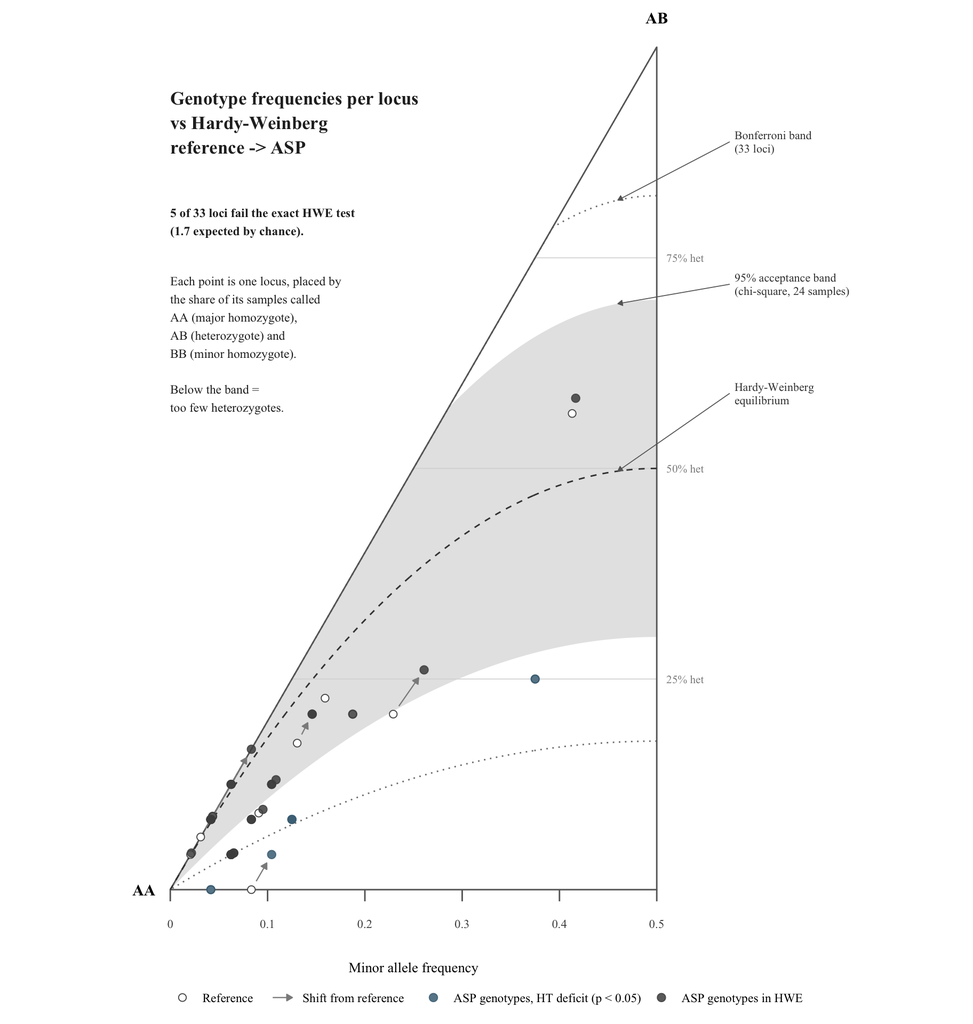

```r
  ggsave(file.path(hwe_ternary_dir, sprintf("hw_ternary_by_locus_%s.png", method_name)), tern_plot, width = 9.5, height = 10, dpi = 300, bg = "white")
  ggsave(file.path(hwe_ternary_dir, sprintf("hw_ternary_by_locus_%s.pdf", method_name)), tern_plot, width = 9.5, height = 10, device = cairo_pdf)
  tern_plot
}

p_tern_asp <- hw_ternary_plot("ASP", "ASP")
p_tern_bayesian <- hw_ternary_plot("ASP_bayesian", "Bayes")
print(p_tern_asp)
```

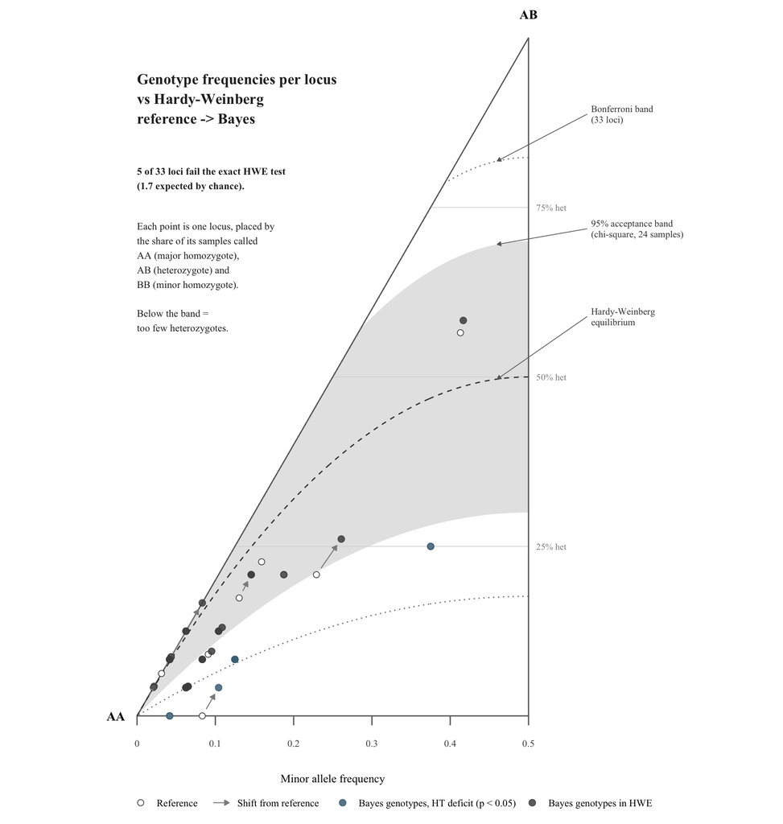

```r
print(p_tern_bayesian)
```

## 5 Depth and HM/HT heatmap

This chunk holds a function for two types of heatmaps, one for depth and one for zygosity. It calls it for both Bayes and ASP genotyper and saves plots automatically into seperate folders. Heatmaps shows all the called genotypes by HM and HT pairs, call with no reference (black outline), wrongly called genotypes (black crosses) and no calls caused by low depth. Note: low depth is set in the master pipeline, for plots created at the moment its set way too low at minimum depth of 3. This should be changed for final results, which would in turn also bring the accuracy of the genotyper closer to 100 %.

```r
make_genotype_plot <- function(asp_df, method_label, ref, out_path, plot_title, type = c("zygosity", "depth"), panel_title = method_label) {
  type <- match.arg(type)
# Read totals order from top to bottom (highest to lowest depth locus) and left to right (highest to lowest depth sample), data preparation
  locus_totals <- asp_df %>%
    group_by(locus) %>%
    summarise(total_reads = sum(depth, na.rm = TRUE)) %>%
    arrange(desc(total_reads))

  sample_totals <- asp_df %>%
    group_by(sample) %>%
    summarise(total_reads = sum(depth, na.rm = TRUE)) %>%
    arrange(desc(total_reads))

  sample_order <- sample_totals$sample
  locus_levels <- rev(locus_totals$locus)

# one row per sample locus pair, calls without a reference keep the value but they are marked with a black outline as no reference calls, pairs which did not produce a call are grey
  method_tiles <- asp_df %>%
    left_join(select(ref, sample, locus, reference = genotype), by = c("sample", "locus"), relationship = "one-to-one") %>%
    mutate(zygosity = case_when(is.na(reference) & is.na(genotype) ~ "No reference",
                                is.na(genotype) ~ "No call",
                                substr(genotype, 1, 1) == substr(genotype, 2, 2) ~ "Homozygous",
                                TRUE ~ "Heterozygous"),
           zygosity = factor(zygosity, levels = c("Homozygous", "Heterozygous", "No call", "No reference")),
           no_reference_call = is.na(reference) & !is.na(genotype),
           locus = factor(locus, levels = locus_levels),
           sample = factor(sample, levels = sample_order))

  no_reference_cells <- filter(method_tiles, no_reference_call) # calls with no reference
  scored_tiles <- filter(method_tiles, !is.na(reference), !is.na(genotype)) # calls with reference

# Plot subtitle preparation, show number of called pairs, number of misscalled pairs and accuracy
  miscall_subtitle <- scored_tiles %>%
    mutate(reference_zygosity = ifelse(substr(reference, 1, 1) == substr(reference, 2, 2), "homozygous", "heterozygous")) %>%
    count(reference_zygosity, miscalled = genotype != reference) %>%
    filter(miscalled) %>%
    mutate(label = sprintf("%d miscalled %s genotype%s", n, reference_zygosity, ifelse(n == 1, "", "s"))) %>%
    pull(label) %>%
    paste(collapse = ", ")

  if (miscall_subtitle == "") miscall_subtitle <- "no miscalled genotypes"
  n_called_with_ref <- nrow(scored_tiles)
  n_correct <- sum(scored_tiles$genotype == scored_tiles$reference)
  accuracy_subtitle <- if (n_called_with_ref == 0) {sprintf("no %s/reference overlap to score", method_label)} else {
    sprintf("%d/%d calls correct (%.1f%% accuracy)", n_correct, n_called_with_ref, 100 * n_correct / n_called_with_ref)
  }

# Call rate over all sample locus pairs, including those without a reference
  n_pairs_total <- length(sample_order) * length(locus_levels)
  n_called_total <- sum(!is.na(method_tiles$genotype))
  call_rate_subtitle <- sprintf("Call rate: %d/%d (%.1f%%)", n_called_total, n_pairs_total, 100 * n_called_total / n_pairs_total)

# Saves pairs with wrong calls
  mismatch_cells <- filter(scored_tiles, genotype != reference)

  heatmap_theme <- theme_minimal(base_family = plot_font, base_size = 8) +
    theme(axis.text.x = element_text(angle = 45, hjust = 1), axis.text.y = element_text(size = 7.5),
          panel.grid = element_blank(), plot.margin = margin(t = -10, r = 2, b = 4, l = 4),
          legend.title = element_text(face = "bold"),
          legend.key.size = unit(14, "pt"),
          legend.key.spacing.y = unit(4, "pt"),
          legend.spacing.y = unit(4, "pt"),
          legend.margin = margin(0, 0, 0, 0))

# black outlines for calls with no reference are drawn a little bit inside the tile so it doesnt touch other cells
no_reference_outline <- geom_tile(data = no_reference_cells, aes(x = sample, y = locus), fill = NA, colour = "black",
                                  linewidth = 0.5, width = 0.9, height = 0.9, inherit.aes = FALSE)

# Because the extra markers are not mapped in aes() they need an extra step for legend. Custom legend entries for the two extra markers, creates marker labels and marker key which creates two entries for legend (shape is mapped to marker with alpha = 0 which makes it transparent)
  marker_labels <- c(sprintf("Called, no reference (%d)", nrow(no_reference_cells)),
                     sprintf("Incorrect call (%d)", nrow(mismatch_cells)))

# Two placeholder rows (one per legend entry) on an existing tile used to create a legend
  marker_key <- data.frame(sample = factor(sample_order[1], levels = sample_order),
                           locus = factor(locus_levels[length(locus_levels)], levels = locus_levels),
                           marker = factor(marker_labels, levels = marker_labels))

# This makes the two figures for two legend entries, one box split diagonally into both colours and one with black outline or X on top
  make_draw_key_marks <- function(fill_low, fill_high) {
    function(data, params, size) { # polygonGrob hold instructions for building a graphical object
      split_tile <- list(polygonGrob(x = c(0, 1, 0), y = c(0, 0, 1), gp = gpar(fill = fill_low, col = NA)), # two triangles for legend
                         polygonGrob(x = c(1, 1, 0), y = c(0, 1, 1), gp = gpar(fill = fill_high, col = NA)))
      mark <- if (data$shape == 0) { # rectGrob makes a rectangle
        rectGrob(width = 1, height = 1, gp = gpar(fill = NA, col = "black", lwd = 1.3)) # gpar set the look of graphical objects - black outline
      } else { # pointsGrob makes points symbols
        pointsGrob(0.5, 0.5, pch = 4, gp = gpar(col = "black", lwd = 2, cex = 0.9)) # X marker on the heatmap
      }
      do.call(grobTree, c(split_tile, list(mark))) # This groups several "grobs" (graphical objects) together, one on top of the other
    }
  }

# geom_point() plots those marker_key entries with shape mapped to marker
  make_marker_legend <- function(fill_low, fill_high) list(
    geom_point(data = marker_key, aes(x = sample, y = locus, shape = marker), alpha = 0, inherit.aes = FALSE, # transparent points
               key_glyph = make_draw_key_marks(fill_low, fill_high)),
    scale_shape_manual(values = setNames(c(0, 4), marker_labels), name = NULL), #
    guides(shape = guide_legend(override.aes = list(alpha = 1), order = 2, byrow = TRUE,
                                theme = theme(legend.title = element_blank()))))
```

```r
# Based on input type it creates a different plot, here the heatmaps actually differ
  if (type == "zygosity") {
    zygosity_fills <- c("Homozygous" = hm_dark, "Heterozygous" = ht_dark, "No call" = no_call_colour, "No reference" = no_reference_colour)

    # Legend labels with numbers of tiles showing results clearly
    zygosity_counts <- table(method_tiles$zygosity) # Counts all four factors of zygosity
    zygosity_labels <- setNames(sprintf("%s (%d)", names(zygosity_counts), as.integer(zygosity_counts)), names(zygosity_counts))

    # Heatmap for zygosity
    panels <- ggplot(method_tiles, aes(x = sample, y = locus, fill = zygosity)) +
      geom_tile(colour = "white", linewidth = 0.2) +
      no_reference_outline +
      geom_point(data = mismatch_cells, aes(x = sample, y = locus, colour = zygosity),
                 shape = 4, size = 2.5, stroke = 1.3, inherit.aes = FALSE, show.legend = FALSE) +
      scale_fill_manual(values = zygosity_fills, labels = zygosity_labels, name = "LEGEND", drop = FALSE) +
      scale_colour_manual(values = c("Homozygous" = "white", "Heterozygous" = "white"), guide = "none") +
      guides(fill = guide_legend(override.aes = list(colour = "grey50", linewidth = 0.3), order = 1, byrow = TRUE)) + # grey border for "No reference"
      make_marker_legend(zygosity_fills[["Homozygous"]], zygosity_fills[["Heterozygous"]]) +
      labs(title = panel_title, x = "Sample", y = "Locus") +
      heatmap_theme +
      theme(plot.title = element_text(hjust = 0.5, face = "bold"), plot.margin = margin(4, 4, 4, 4))

    combined_layout <- plot_layout(guides = "collect") # Legend on the right side, using patchwork for consistency with the depth heatmap
  } else {

# 2.Plot: Depth heatmap with sample depth on top and locus depth on the right side (ordered)
    # Only two axis marks so one in the middle and one for max value
    orientation_breaks <- function(totals) signif(c(max(totals) / 2, max(totals)), 2)
    reads_axis_labels <- label_number(scale = 1e-3, suffix = "k", accuracy = 1)

    # First panel for sample depth
    p_sample_reads <- ggplot(sample_totals %>%
                            mutate(sample = factor(sample, levels = sample_order)), aes(x = sample, y = total_reads)) +
      geom_col(fill = "grey50", width = 0.8) +
      scale_y_continuous(limits = c(0, NA), breaks = orientation_breaks(sample_totals$total_reads), labels = reads_axis_labels,
                         expand = expansion(mult = c(0, 0.08))) +
      theme_minimal(base_family = plot_font, base_size = 8) +
      theme(axis.text.x = element_blank(), axis.title.x = element_blank(),
            panel.grid.minor = element_blank(), panel.grid.major.x = element_blank(),
            plot.title = element_text(hjust = 0.5, face = "bold")) +
      labs(y = "Reads", title = panel_title)

    # Second panel for locus depth
    p_locus_reads <- ggplot(locus_totals %>%
                              mutate(locus = factor(locus, levels = locus_levels)), aes(x = total_reads, y = locus)) +
      geom_col(fill = "grey50", width = 0.8) +
      scale_x_continuous(limits = c(0, NA), breaks = orientation_breaks(locus_totals$total_reads), labels = reads_axis_labels,
                         expand = expansion(mult = c(0, 0.08))) +
      theme_minimal(base_family = plot_font, base_size = 8) +
      theme(axis.text.y = element_blank(), axis.title.y = element_blank(),
            panel.grid.minor = element_blank(), panel.grid.major.y = element_blank()) +
      labs(x = "Reads")

    # Main panel showing depth heatmap
    p_main <- ggplot(method_tiles, aes(x = sample, y = locus)) +
      geom_tile(data = filter(method_tiles, !is.na(genotype)), aes(fill = depth), colour = "white", linewidth = 0.2) +
      geom_tile(data = filter(method_tiles, zygosity == "No call"), fill = no_call_colour, colour = "white", linewidth = 0.2) +
      geom_tile(data = filter(method_tiles, zygosity == "No reference"), fill = no_reference_colour, colour = "white", linewidth = 0.2) +
      no_reference_outline +
      geom_point(data = mismatch_cells, aes(x = sample, y = locus), shape = 4, size = 2, stroke = 1.3, colour = "black", inherit.aes = FALSE) +
      make_marker_legend("#A4B591", "#A4B591") +
      scale_fill_gradient(low = "#F1E4DB", high = "#2C5724", transform = "log1p", name = "Depth (reads)", # log because it goes from 3 to 3000
                          breaks = c(3, 10, 30, 100, 300, 1000, 3000), labels = label_comma(),
                          guide = guide_colourbar(order = 1)) +
      labs(x = "Sample", y = "Locus") +
      heatmap_theme

    # Plot is split into 11 column, 9 for heatmap, 1 for locus reads  and one for legends and 10 rows 1 for sample reads and 9 for heatmap
    layout <- c(area(t = 1, l = 1, b = 1, r = 9),
                area(t = 2, l = 1, b = 10, r = 9),
                area(t = 2, l = 10, b = 10, r = 10),
                area(t = 2, l = 11, b = 10, r = 12))
    panels <- p_sample_reads + p_main + p_locus_reads + guide_area()
    combined_layout <- plot_layout(design = layout, guides = "collect")}

 # Combines the panels and layout and saves the plots
  p_combined <- panels +
    combined_layout +
    plot_annotation(title = plot_title, # Annotation and legend theme for the whole plot not separate panels
                            subtitle = sprintf("%s | %s vs reference: %s | %s", call_rate_subtitle, method_label, miscall_subtitle, accuracy_subtitle),
                            theme = theme(plot.title = element_text(hjust = 0.5, face = "bold"),
                                             plot.subtitle = element_text(hjust = 0.5),
                                             legend.spacing.y = unit(4, "pt"),
                                             legend.justification = c(0, 0.5),
                                             legend.box.margin = margin(0, 0, 0, -10)))

  # saving in landscape both plots
  ggsave(out_path, p_combined, width = 11.69, height = 8.27, dpi = 300, bg = "white")
  ggsave(sub("\\.png$", ".pdf", out_path), p_combined, width = 11.69, height = 8.27, device = cairo_pdf)
```

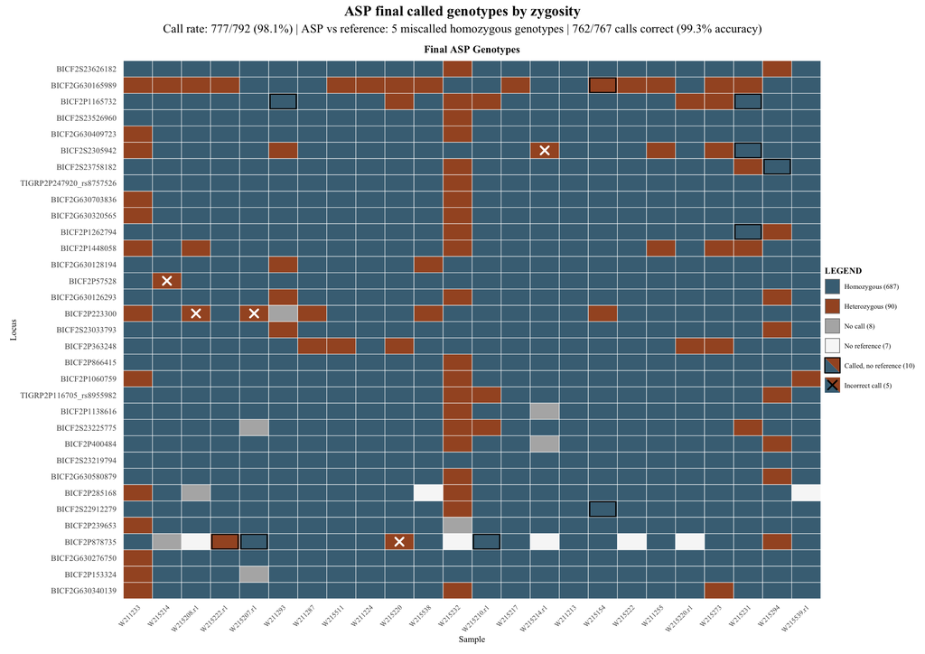

```r
  p_combined
}

### Function calling

identified_genotypes <- transmute(asp_results, sample = barcode, locus, genotype, depth) # ASP calls with their read depth
bayes_genotypes <- transmute(bayes_raw, sample = barcode, locus, genotype, depth) # Bayesian calls with their read depth
mm2_genotypes <- transmute(mm2_raw, sample = barcode, locus, genotype, depth) # Minimap 2 calls with their read depth

identified_zygosity_plot <- make_genotype_plot(identified_genotypes, "ASP", ref,
                                               out_path = file.path(out_dir, "genotype_zygosity_heatmap.png"),
                                               plot_title = "ASP final called genotypes by zygosity",
                                               type = "zygosity", panel_title = "Final ASP Genotypes")

identified_depth_plot <- make_genotype_plot(identified_genotypes, "ASP", ref,
                                            out_path = file.path(out_dir, "genotype_depth_heatmap.png"),
                                            plot_title = "ASP final called genotypes by read depth",
                                            type = "depth", panel_title = "Final ASP Genotypes")

bayes_zygosity_plot <- make_genotype_plot(bayes_genotypes, "Bayesian ASP", ref,
                                          out_path = file.path(bayes_out_dir, "genotype_zygosity_heatmap_bayesian.png"),
                                          plot_title = "Bayesian ASP final called genotypes by zygosity",
                                          type = "zygosity", panel_title = "Final Bayesian ASP Genotypes")

bayes_depth_plot <- make_genotype_plot(bayes_genotypes, "Bayesian ASP", ref,
                                       out_path = file.path(bayes_out_dir, "genotype_depth_heatmap_bayesian.png"),
                                       plot_title = "Bayesian ASP final called genotypes by read depth",
                                       type = "depth", panel_title = "Final Bayesian ASP Genotypes")

mm2_zygosity_plot <- make_genotype_plot(mm2_genotypes, "Minimap2", ref,
                                        out_path = file.path(mm2_out_dir, "genotype_zygosity_heatmap_minimap2.png"),
                                        plot_title = "Minimap2 final called genotypes by zygosity",
                                        type = "zygosity", panel_title = "Final Minimap2 Genotypes")

mm2_depth_plot <- make_genotype_plot(mm2_genotypes, "Minimap2", ref,
                                     out_path = file.path(mm2_out_dir, "genotype_depth_heatmap_minimap2.png"),
                                     plot_title = "Minimap2 final called genotypes by read depth",
                                     type = "depth", panel_title = "Final Minimap2 Genotypes")

print(identified_zygosity_plot)
```

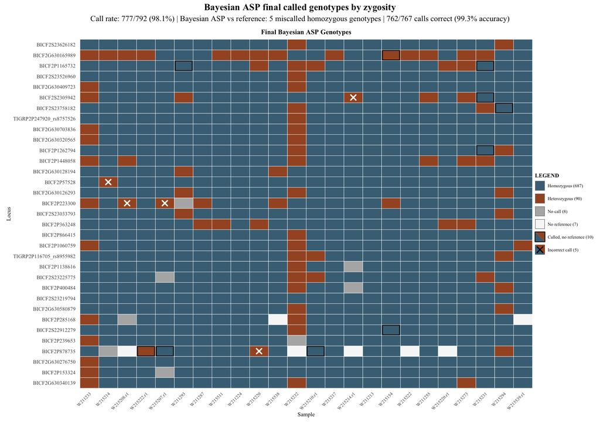

```r
print(bayes_zygosity_plot)
```

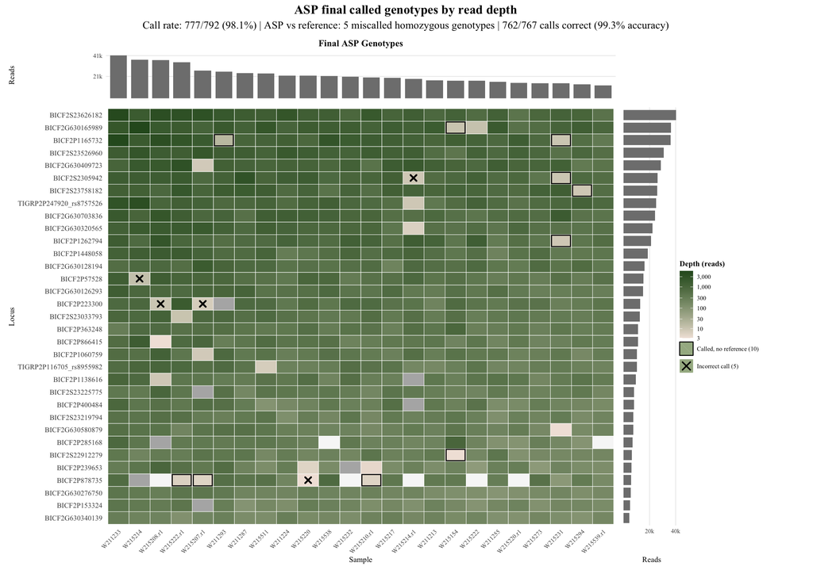

```r
print(identified_depth_plot)
```

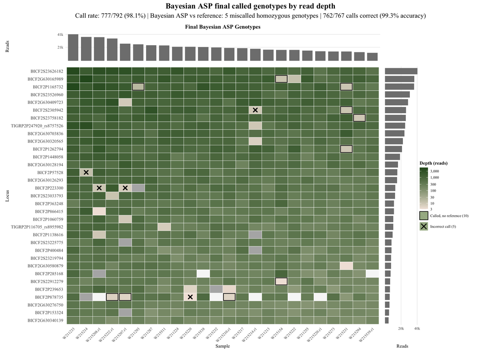

```r
print(bayes_depth_plot)
```

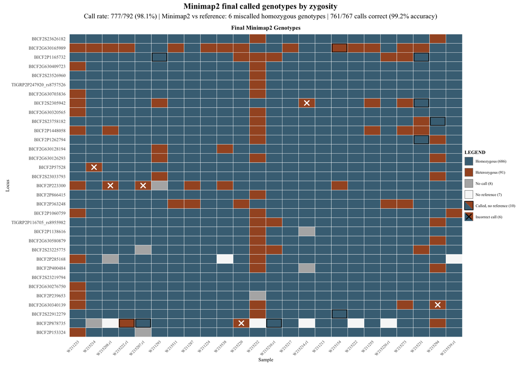

```r
print(mm2_zygosity_plot)
```

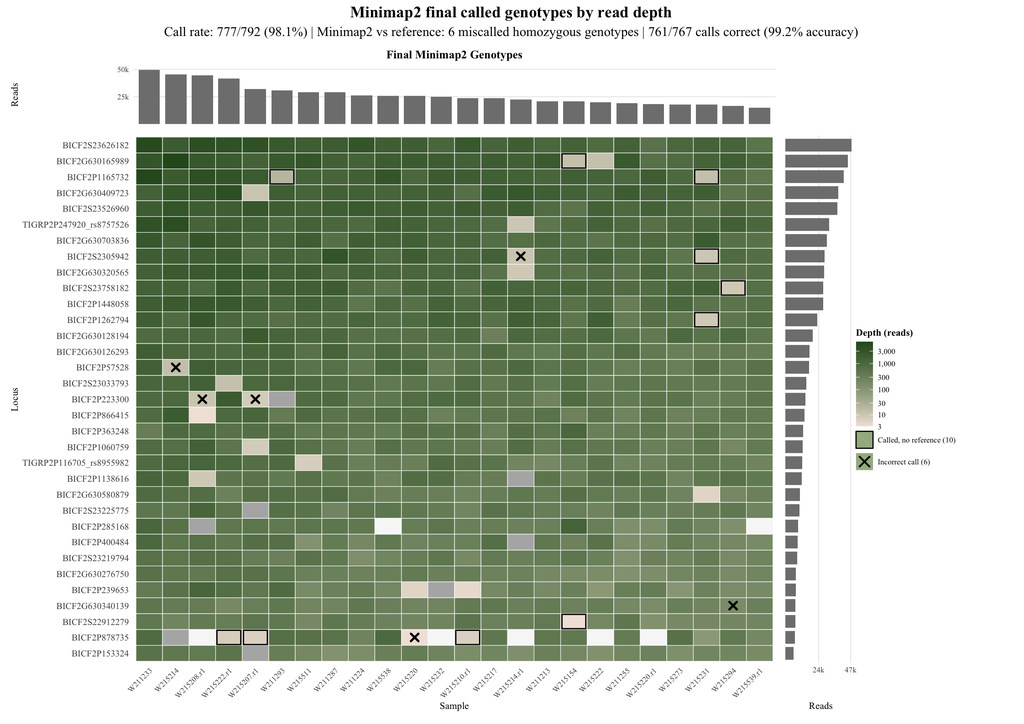

```r
print(mm2_depth_plot)
```

## 6 Downsampling and calibration plots

This chunk makes three plots for downsampling and calibration visualsation, comparison of error rates between HM and HT against read depth, paired difference between stan and naive caller showing how many miscalls are made, and the GQ threshold simulation for using it as a filter.

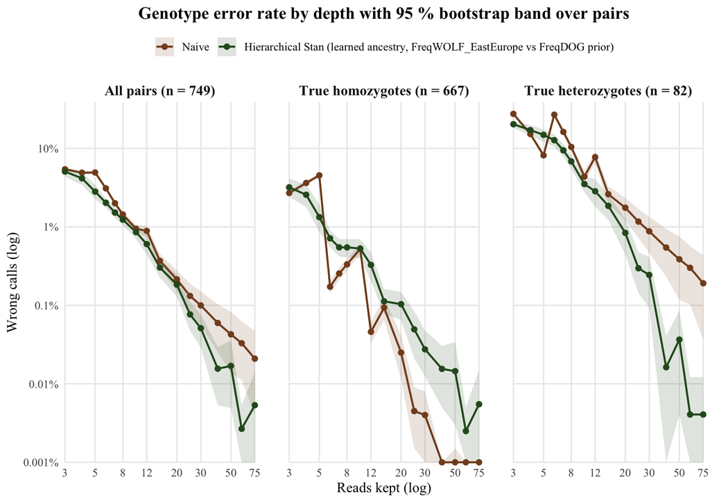

```r
### Chunk for plotting the calibration and other results from 05b
# Reading saves results so plotting chunks can be run without stan
if (!exists("downsampling_plot_inputs")) {
  stopifnot("no saved run with these settings, run the downsampling first" = file.exists(file.path(downsampling_output_folder, "downsampling_plot_inputs.rds")))
  downsampling_plot_inputs <- readRDS(file.path(downsampling_output_folder, "downsampling_plot_inputs.rds"))
}
invisible(list2env(downsampling_plot_inputs[names(downsampling_plot_inputs) != "downsampling_output_folder"], envir = environment()))

# Plot settings
depths_in_tradeoff_graph <- c(4, 6, 8, 10, 15, 20)
depth_colours <- setNames(colorRampPalette(c(error_colour, "#AB5D26", "#D9A877", "#E1C473", correct_colour, "#2C5724"))(length(depths_in_tradeoff_graph)),
                          paste(depths_in_tradeoff_graph, "reads"))
lowest_plotted_error <- 1e-5 # zero errors are drawn at 0.001 % on the log scales
caller_colours <- c("Naive" = "#834D24", "Hierarchical Stan" = "#2C5724")
downsampling_theme <- theme_minimal(base_family = plot_font, base_size = 12) +
  theme(plot.title = element_text(face = "bold", hjust = 0.5),
        plot.subtitle = element_text(hjust = 0.5, size = 10),
        strip.text = element_text(face = "bold", size = 12),
        legend.position = "top",
        panel.grid.minor = element_blank())

### 1. Plot, error rate against read depth
group_pair_counts <- distinct(error_by_depth_table, group, n_pairs) # one row per group, n_pairs is the same at every depth
group_panel_labels <- setNames(sprintf("%s (n = %d)", group_pair_counts$group, group_pair_counts$n_pairs), group_pair_counts$group)

error_plot_data <- bind_rows(
  error_by_depth_table %>% transmute(group, depth, caller = "Naive", error_rate = Naive, band_low = naive_low, band_high = naive_high),
  error_by_depth_table %>% transmute(group, depth, caller = "Hierarchical Stan", error_rate = `Hierarchical Stan`, band_low = stan_low, band_high = stan_high)
) %>%
  mutate(caller = factor(caller, levels = names(caller_colours)),
         across(c(error_rate, band_low, band_high), ~ pmax(.x, lowest_plotted_error))) # log scale cannot show 0

error_by_depth_plot <- ggplot(error_plot_data, aes(x = depth, y = error_rate, colour = caller, fill = caller)) +
  geom_ribbon(aes(ymin = band_low, ymax = band_high), alpha = 0.15, colour = NA) +
  geom_line(linewidth = 0.8) +
  geom_point(size = 1.8) +
  facet_wrap(~ group, labeller = as_labeller(group_panel_labels)) +
  scale_x_log10(breaks = c(3, 5, 8, 12, 20, 30, 50, 75), expand = c(0, 0)) +
  coord_cartesian(clip = "off") +
  scale_y_log10(labels = label_percent(accuracy = 0.001, drop0trailing = TRUE), breaks = c(1e-5, 1e-4, 1e-3, 1e-2, 1e-1),
                expand = expansion(mult = c(0, 0.03))) +
  scale_colour_manual(values = caller_colours, labels = c("Naive" = "Naive", "Hierarchical Stan" = sprintf("Hierarchical Stan (%s prior)", prior_description))) +
  scale_fill_manual(values = caller_colours, labels = c("Naive" = "Naive", "Hierarchical Stan" = sprintf("Hierarchical Stan (%s prior)", prior_description))) +
  labs(title = "Genotype error rate by depth with 95 % bootstrap band over pairs",
       x = "Reads kept (log)", y = "Wrong calls (log)", colour = NULL, fill = NULL) +
  downsampling_theme +
  theme(panel.spacing.x = unit(2, "lines"))
print(error_by_depth_plot)
```

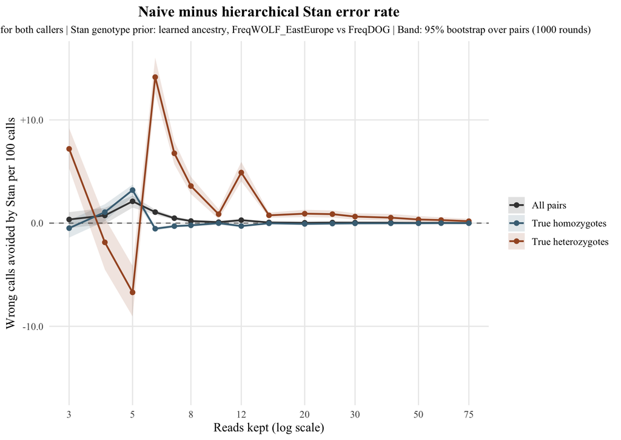

```r
### 2. Plot, paired difference naive - Stan
# Paired difference between naive and stan caller on the same draws (if its above zero Stan makes fewer errors)
caller_difference_plot <- ggplot(error_by_depth_table, aes(x = depth, y = difference, colour = group, fill = group)) +
  geom_hline(yintercept = 0, linetype = "dashed", colour = "grey50") +
  geom_blank(aes(y = -difference_low)) + # invisible mirrored band, so the y axis is symmetric around 0
  geom_blank(aes(y = -difference_high)) +
  geom_ribbon(aes(ymin = difference_low, ymax = difference_high), alpha = 0.15, colour = NA) +
  geom_line(linewidth = 0.8) +
  geom_point(size = 1.8) +
  scale_x_log10(breaks = c(3, 5, 8, 12, 20, 30, 50, 75)) +
  scale_y_continuous(labels = label_number(scale = 100, accuracy = 0.1, style_positive = "plus")) +
  scale_colour_manual(values = group_colours) +
  scale_fill_manual(values = group_colours) +
  labs(title = "Naive minus hierarchical Stan error rate",
       subtitle = sprintf("Same draws for both callers | Stan genotype prior: %s | Band: 95%% bootstrap over pairs (%d rounds)",
                          prior_description, bootstrap_rounds),
       x = "Reads kept (log scale)", y = "Wrong calls avoided by Stan per 100 calls", colour = NULL, fill = NULL) +
  downsampling_theme +
  theme(legend.position = "right")
print(caller_difference_plot)
```

```r
### 3. Plot, GQ cut-off trade-off
# GQ as a filter: per depth, share of all calls removed (cost) against share of wrong calls removed (gain), one point per threshold
gq_tradeoff_plot_data <- gq_tradeoff_table %>%
  filter(depth %in% depths_in_tradeoff_graph, !is.na(share_errors_removed)) %>%
  mutate(share_removed = 1 - share_kept,
         overall_error = error_among_kept[gq_threshold == min(gq_threshold)],
         share_correct_removed = (share_removed - overall_error * share_errors_removed) / (1 - overall_error),
         youden_index = share_errors_removed - share_correct_removed,
         depth_label = factor(paste(depth, "reads"), levels = names(depth_colours)), .by = depth) %>%
  arrange(depth, gq_threshold)

# Best threshold per depth
best_threshold_points <- gq_tradeoff_plot_data %>% slice_max(youden_index, n = 1, with_ties = FALSE, by = depth)
kable(best_threshold_points %>%
        transmute(depth, gq_threshold, 100 * share_kept, 100 * share_errors_removed, 100 * share_correct_removed, 100 * error_among_kept),
      digits = c(0, 0, 1, 1, 1, 3),
      col.names = c("Reads", "Best GQ threshold", "Calls kept (%)", "Wrong calls removed (%)", "Correct calls removed (%)", "Error among kept (%)"),
      caption = "Best GQ threshold per depth (largest Youden index)")
```

Best GQ threshold per depth (largest Youden index)

| Reads | Best GQ threshold | Calls kept (%) | Wrong calls removed (%) | Correct calls removed (%) | Error among kept (%) |
| --- | --- | --- | --- | --- | --- |
| 4 | 14 | 86.2 | 84.6 | 10.8 | 0.743 |
| 6 | 19 | 84.6 | 90.4 | 13.8 | 0.230 |
| 8 | 21 | 87.3 | 93.4 | 11.7 | 0.093 |
| 10 | 17 | 92.5 | 91.8 | 6.8 | 0.076 |
| 15 | 27 | 90.5 | 98.1 | 9.3 | 0.006 |
| 20 | 26 | 97.4 | 96.6 | 2.4 | 0.006 |

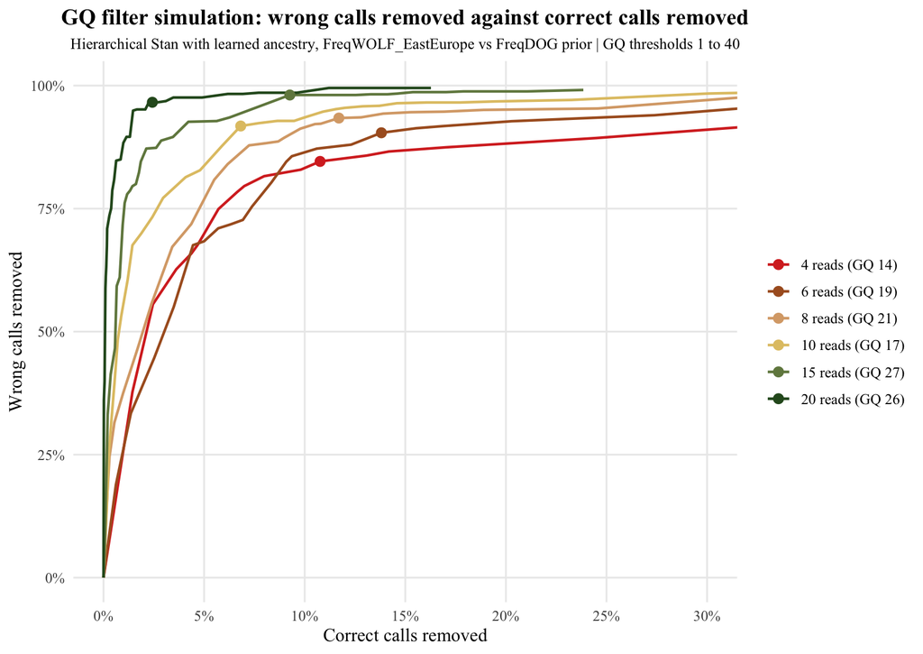

```r
# Legend entries with each depth's best threshold
depth_legend_labels <- setNames(sprintf("%s (GQ %d)", best_threshold_points$depth_label, best_threshold_points$gq_threshold),
                                best_threshold_points$depth_label)

gq_tradeoff_plot <- ggplot(gq_tradeoff_plot_data, aes(x = share_correct_removed, y = share_errors_removed, colour = depth_label)) +
  geom_path(linewidth = 0.8) +
  geom_point(data = best_threshold_points, size = 2.6) + # best threshold per depth
  scale_x_continuous(labels = percent, breaks = seq(0, 0.3, 0.05)) +
  scale_y_continuous(labels = percent, breaks = seq(0, 1, 0.25)) +
  scale_colour_manual(values = depth_colours, labels = depth_legend_labels) +
  coord_cartesian(xlim = c(0, 0.3), ylim = c(0, 1)) +
  labs(title = "GQ filter simulation: wrong calls removed against correct calls removed",
       subtitle = sprintf("Hierarchical Stan with %s prior | GQ thresholds %s to %s",
                          prior_description, min(gq_tradeoff_plot_data$gq_threshold), max(gq_tradeoff_plot_data$gq_threshold)),
       x = "Correct calls removed", y = "Wrong calls removed", colour = NULL) +
  downsampling_theme +
  theme(legend.position = "right")
print(gq_tradeoff_plot)
```

```r
### Saving plots
ggsave(file.path(downsampling_output_folder, "error_vs_depth.png"), error_by_depth_plot, width = 8.27, height = 5.85, dpi = 300, bg = "white")
ggsave(file.path(downsampling_output_folder, "error_vs_depth.pdf"), error_by_depth_plot, width = 8.27, height = 5.85, device = cairo_pdf)
ggsave(file.path(downsampling_output_folder, "caller_difference.png"), caller_difference_plot, width = 8.27, height = 5.85, dpi = 300, bg = "white")
ggsave(file.path(downsampling_output_folder, "caller_difference.pdf"), caller_difference_plot, width = 8.27, height = 5.85, device = cairo_pdf)
ggsave(file.path(downsampling_output_folder, "gq_cutoff_tradeoff.png"), gq_tradeoff_plot, width = 8.27, height = 5.85, dpi = 300, bg = "white")
ggsave(file.path(downsampling_output_folder, "gq_cutoff_tradeoff.pdf"), gq_tradeoff_plot, width = 8.27, height = 5.85, device = cairo_pdf)
```

## 7 Genotype Calibration Plot

This chunk contains data prep and genotype calibration plot.

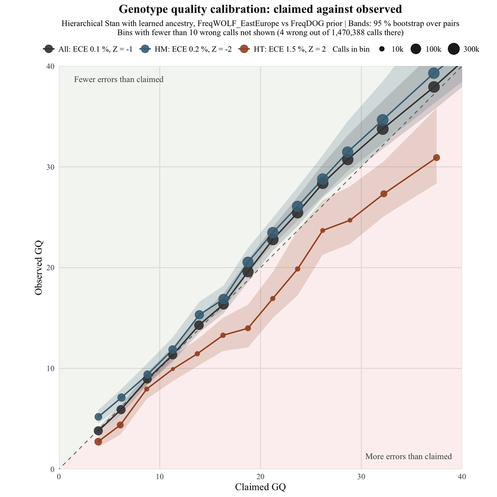

```r
### Calibration plot: HM and HT with bands
calibration_colours <- c("All calls" = "grey25", "Homozygous calls" = hm_dark, "Heterozygous calls" = ht_dark)

calibration_verdicts <- calibration_statistics_table %>%
  mutate(legend_label = sprintf("%s: ECE %.1f %%, Z = %.0f",
                                c("All calls" = "All", "Homozygous calls" = "HM", "Heterozygous calls" = "HT")[as.character(group)],
                                100 * ece, spiegelhalter_z_cluster))
calibration_legend_labels <- setNames(calibration_verdicts$legend_label, as.character(calibration_verdicts$group))

minimum_wrong_calls_per_bin <- 10 # an error rate needs enough wrong calls to be measured, bins with fewer are left out
calibration_bins <- calibration_table %>% filter(group != "All calls") %>% mutate(group = droplevels(group))
calibration_plot_data <- calibration_table %>%
  filter(n_wrong >= minimum_wrong_calls_per_bin) %>%
  mutate(group = factor(group, levels = calibration_groups)) # All calls, HM, HT in this order

hidden_bins <- calibration_bins %>% filter(n_wrong < minimum_wrong_calls_per_bin)
hidden_note <- sprintf("Bins with fewer than %d wrong calls not shown (%d wrong out of %s calls there)",
                       minimum_wrong_calls_per_bin, sum(hidden_bins$n_wrong), comma(sum(hidden_bins$n)))
phred_breaks <- seq(0, 40, 10)

calibration_plot <- ggplot(calibration_plot_data, aes(x = claimed_Q, y = empirical_Q, colour = group)) +
  annotate("polygon", x = c(0, 40, 0), y = c(0, 40, 40), fill = correct_colour, alpha = 0.08) + # background colour
  annotate("polygon", x = c(0, 40, 40), y = c(0, 0, 40), fill = error_colour, alpha = 0.08) +
  annotate("text", x = 1.5, y = 39, label = "Fewer errors than claimed", hjust = 0, vjust = 1, size = 3.6, colour = "grey30", family = plot_font) +
  annotate("text", x = 39, y = 1, label = "More errors than claimed", hjust = 1, vjust = 0, size = 3.6, colour = "grey30", family = plot_font) +
  geom_abline(slope = 1, intercept = 0, linetype = "dashed", colour = "grey50") +
  geom_ribbon(aes(ymin = bar_Q_low, ymax = bar_Q_high, fill = group), alpha = 0.18, colour = NA) +
  geom_path(linewidth = 0.8) +
  geom_point(aes(size = n), alpha = 0.9) +
  scale_colour_manual(values = calibration_colours, labels = calibration_legend_labels, name = NULL) +
  scale_fill_manual(values = calibration_colours, guide = "none") +
  scale_size_continuous(transform = "log10", range = c(1.5, 6), breaks = c(10000, 100000, 300000),
                        labels = label_number(scale = 1e-3, suffix = "k"), name = "Calls in bin") +
  scale_x_continuous(breaks = phred_breaks) +
  scale_y_continuous(breaks = phred_breaks) +
  coord_equal(xlim = c(0, 40), ylim = c(0, 40), expand = FALSE) +
  guides(colour = guide_legend(order = 1, nrow = 1, override.aes = list(size = 4)), size = guide_legend(order = 2, nrow = 1)) +
  labs(title = "Genotype quality calibration: claimed against observed",
       subtitle = sprintf("Hierarchical Stan with %s prior | Bands: 95 %% bootstrap over pairs\n%s",
                          prior_description, hidden_note),
       x = "Claimed GQ", y = "Observed GQ") +
  downsampling_theme +
  theme(legend.box = "horizontal",
        legend.title = element_text(size = rel(0.8)),
        legend.text = element_text(margin = margin(l = 3)),
        legend.key.spacing.x = unit(6, "pt"),
        legend.spacing.x = unit(8, "pt"),
        legend.margin = margin(0, 0, 0, 0))
print(calibration_plot)
```

```r
ggsave(file.path(downsampling_output_folder, "genotype_calibration.png"), calibration_plot, width = 8.27, height = 8.27, dpi = 300, bg = "white")
ggsave(file.path(downsampling_output_folder, "genotype_calibration.pdf"), calibration_plot, width = 8.27, height = 8.27, device = cairo_pdf)
```

## 8 Genotype Prior Comparison Plots

This chunk contains comparison plots between different priors used on the same settings, it contains data prep and plot for error rate and genotype calibration comparison.

```r
### Prior comparison plot with same settings but three different priors
# Importing the files
comparison_parent_folder <- file.path("Results", dataset_name, "Graphics", "STAN_Hierarchical")
comparison_folders <- file.path(comparison_parent_folder, c(
  "unpad_a3_e0.08_flat",
  "unpad_a3_e0.08_het0.15",
  "unpad_a3_e0.08_hwe_Wall_fl0.001",
  "unpad_a3_e0.08_anc_Wall_fl0.001_b1",
  "unpad_a3_e0.08_anc_WEastEurope_fl0.001_b1"), "Downsampling_calibration_sflag_r75_d75_n300") # run folders, then the downsampling folder inside each
comparison_folders <- comparison_folders[file.exists(file.path(comparison_folders, "downsampling_plot_inputs.rds"))] # runs that don't exist (yet) are skipped
prior_palette <- c("#E0A526", "#2F6690", "#8E5C8E", "#C2502E", "#5E8C3A")

# Saved results of each run, all runs must share the same truth set
comparison_runs <- lapply(comparison_folders, function(folder) readRDS(file.path(folder, "downsampling_plot_inputs.rds")))
stopifnot("the runs have different truth sets" = length(unique(sapply(comparison_runs, `[[`, "n_truth_pairs"))) == 1)
comparison_prior_names <- sapply(comparison_runs, `[[`, "prior_description")
prior_colours <- setNames(prior_palette, comparison_prior_names)

# Summary table: one row per prior and call type
kable(bind_rows(lapply(comparison_runs, function(run) mutate(run$calibration_statistics_table, prior = run$prior_description))) %>%
        transmute(prior, group, n_calls,
                  claimed_error_pct = round(100 * mean_claimed_error, 2), observed_error_pct = round(100 * observed_error, 2),
                  ece_pct = round(100 * ece, 2), spiegelhalter_z_cluster = round(spiegelhalter_z_cluster, 1),
                  brier = signif(brier, 3), brier_skill_score = round(brier_skill_score, 3)),
      col.names = c("Prior", "Calls", "n", "Claimed error (%)", "Observed error (%)", "ECE (%)", "Spiegelhalter Z", "Brier", "Brier skill"),
      format.args = list(big.mark = ","))
```

| Prior | Calls | n | Claimed error (%) | Observed error (%) | ECE (%) | Spiegelhalter Z | Brier | Brier skill |
| --- | --- | --- | --- | --- | --- | --- | --- | --- |
| flat | All calls | 3,595,200 | 2.55 | 1.79 | 1.11 | -14.6 | 0.01420 | 0.194 |
| flat | Homozygous calls | 3,180,527 | 2.25 | 0.68 | 1.57 | -14.9 | 0.00754 | -0.114 |
| flat | Heterozygous calls | 414,673 | 4.86 | 10.31 | 5.45 | 12.2 | 0.06510 | 0.295 |
| het share 0.15 | All calls | 3,370,500 | 1.74 | 1.62 | 0.25 | -2.3 | 0.01260 | 0.214 |
| het share 0.15 | Homozygous calls | 3,011,560 | 1.31 | 1.08 | 0.26 | -2.4 | 0.00904 | 0.151 |
| het share 0.15 | Heterozygous calls | 358,940 | 5.31 | 6.23 | 0.92 | 2.5 | 0.04200 | 0.280 |
| FreqWOLF_all | All calls | 3,370,500 | 1.35 | 3.16 | 1.81 | 5.7 | 0.02470 | 0.195 |
| FreqWOLF_all | Homozygous calls | 2,966,041 | 0.87 | 1.20 | 0.46 | 3.2 | 0.01030 | 0.129 |
| FreqWOLF_all | Heterozygous calls | 404,459 | 4.86 | 17.55 | 12.69 | 4.5 | 0.13000 | 0.103 |
| learned ancestry, FreqWOLF_all vs FreqDOG | All calls | 3,595,200 | 1.27 | 1.24 | 0.17 | -1.4 | 0.00925 | 0.245 |
| learned ancestry, FreqWOLF_all vs FreqDOG | Homozygous calls | 3,202,250 | 0.98 | 0.71 | 0.28 | -3.0 | 0.00610 | 0.131 |
| learned ancestry, FreqWOLF_all vs FreqDOG | Heterozygous calls | 392,950 | 3.65 | 5.60 | 1.95 | 3.0 | 0.03490 | 0.339 |
| learned ancestry, FreqWOLF_EastEurope vs FreqDOG | All calls | 3,595,200 | 1.21 | 1.18 | 0.08 | -0.9 | 0.00890 | 0.239 |
| learned ancestry, FreqWOLF_EastEurope vs FreqDOG | Homozygous calls | 3,203,787 | 0.91 | 0.70 | 0.21 | -2.2 | 0.00602 | 0.132 |
| learned ancestry, FreqWOLF_EastEurope vs FreqDOG | Heterozygous calls | 391,413 | 3.69 | 5.15 | 1.47 | 2.5 | 0.03250 | 0.335 |

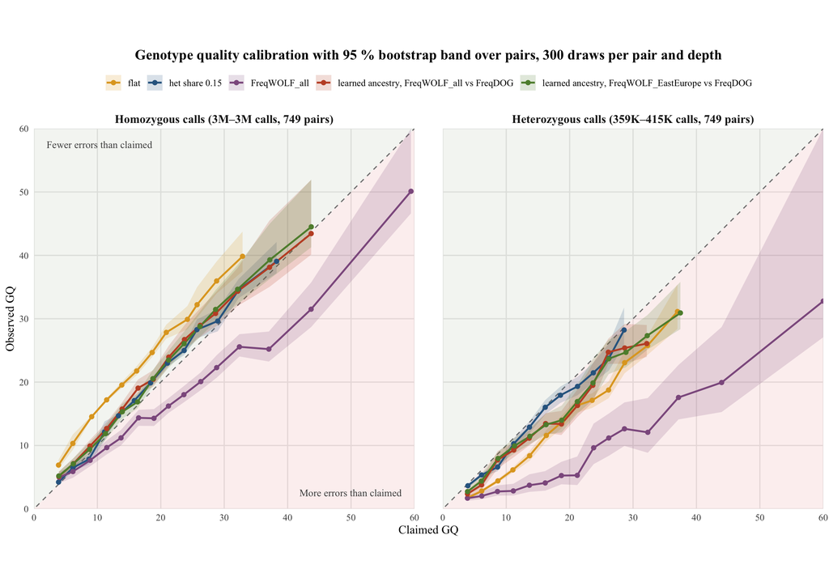

```r
# Calibration: bins with enough wrong calls, one line per prior, homozygous and heterozygous calls in separate panels
calibration_comparison_data <- bind_rows(lapply(comparison_runs, function(run) mutate(run$calibration_table, prior = run$prior_description))) %>%
  filter(group != "All calls", n_wrong >= minimum_wrong_calls_per_bin) %>%
  mutate(group = factor(group, levels = c("Homozygous calls", "Heterozygous calls")),
         prior = factor(prior, levels= comparison_prior_names))

# Panel titles with the number of calls in each group, as a range over the priors (each prior calls a few more or fewer homozygotes)
calls_per_group <- bind_rows(lapply(comparison_runs, function(run) run$calibration_statistics_table)) %>%
  filter(group != "All calls") %>%
  summarise(fewest = min(n_calls), most = max(n_calls), .by = group)
calibration_panel_labels <- setNames(sprintf("%s (%s\u2013%s calls, %d pairs)", calls_per_group$group,
                                             label_number(scale_cut = cut_short_scale())(signif(calls_per_group$fewest, 3)),
                                             label_number(scale_cut = cut_short_scale())(signif(calls_per_group$most, 3)),
                                             comparison_runs[[1]]$n_truth_pairs), # calls of both panels come from the whole truth set
                                     calls_per_group$group)

calibration_comparison_plot <- ggplot(calibration_comparison_data, aes(x = claimed_Q, y = empirical_Q, colour = prior, fill = prior)) +
  annotate("polygon", x = c(0, 60, 0), y = c(0, 60, 60), fill = correct_colour, alpha = 0.08) +
  annotate("polygon", x = c(0, 60, 60), y = c(0, 0, 60), fill = error_colour, alpha = 0.08) +
  geom_text(data = data.frame(group = factor("Homozygous calls", levels = c("Homozygous calls", "Heterozygous calls")),
                              x = c(2, 58), y = c(58, 2), label = c("Fewer errors than claimed", "More errors than claimed"),
                              hjust = c(0, 1), vjust = c(1, 0)),
            aes(x = x, y = y, label = label, hjust = hjust, vjust = vjust),
            size = 3.6, colour = "grey30", family = plot_font, inherit.aes = FALSE) +
  geom_abline(slope = 1, intercept = 0, linetype = "dashed", colour = "grey50") +
  geom_ribbon(aes(ymin = bar_Q_low, ymax = bar_Q_high), alpha = 0.18, colour = NA) +
  geom_path(linewidth = 0.9) +
  geom_point(size = 1.8) +
  facet_wrap(~ group, labeller = as_labeller(calibration_panel_labels)) +
  scale_colour_manual(values = prior_colours) +
  scale_fill_manual(values = prior_colours) +
  scale_x_continuous(breaks = seq(0, 60, 10)) +
  scale_y_continuous(breaks = seq(0, 60, 10)) +
  coord_equal(xlim = c(0, 60), ylim = c(0, 60), expand = FALSE) +
  guides(colour = guide_legend(nrow = 1), fill = guide_legend(nrow = 1)) +
  labs(title = sprintf("Genotype quality calibration with 95 %% bootstrap band over pairs, %d draws per pair and depth",
                       comparison_runs[[1]]$draws_per_depth),
       x = "Claimed GQ", y = "Observed GQ", colour = NULL, fill = NULL) +
    downsampling_theme +
  theme(panel.spacing.x = unit(2, "lines")) # space between the two panels
print(calibration_comparison_plot)
```

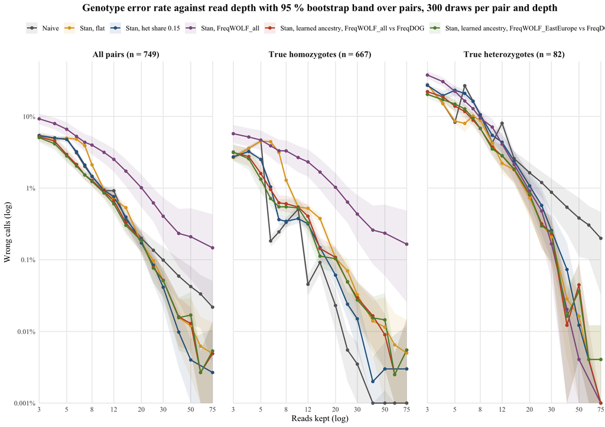

```r
# Error rate against depth: the naive caller once (same draws in every run) and Stan once per prior
error_comparison_data <- bind_rows(
  comparison_runs[[1]]$error_by_depth_table %>%
    transmute(group, depth, line = "Naive", error_rate = Naive, band_low = naive_low, band_high = naive_high),
  bind_rows(lapply(comparison_runs, function(run) mutate(run$error_by_depth_table, prior = run$prior_description))) %>%
    transmute(group, depth, line = paste("Stan,", prior), error_rate = `Hierarchical Stan`, band_low = stan_low, band_high = stan_high)) %>%
  mutate(line = factor(line, levels = c("Naive", paste("Stan,", comparison_prior_names))),
         across(c(error_rate, band_low, band_high), ~ pmax(.x, lowest_plotted_error))) # log scale cannot show 0
error_line_colours <- setNames(c("grey40", prior_colours), c("Naive", paste("Stan,", comparison_prior_names)))


group_pair_counts <- distinct(comparison_runs[[1]]$error_by_depth_table, group, n_pairs)
group_panel_labels <- setNames(sprintf("%s (n = %d)", group_pair_counts$group, group_pair_counts$n_pairs), group_pair_counts$group)

error_comparison_plot <- ggplot(error_comparison_data, aes(x = depth, y = error_rate, colour = line, fill = line)) +
  geom_ribbon(aes(ymin = band_low, ymax = band_high), alpha = 0.1, colour = NA) +
  geom_line(linewidth = 0.8) +
  geom_point(size = 1.5) +
  facet_wrap(~ group, labeller = as_labeller(group_panel_labels)) +
  scale_x_log10(breaks = c(3, 5, 8, 12, 20, 30, 50, 75), expand = c(0, 0)) +
  coord_cartesian(clip = "off") +
  scale_y_log10(labels = label_percent(accuracy = 0.001, drop0trailing = TRUE), breaks = c(1e-5, 1e-4, 1e-3, 1e-2, 1e-1),
                expand = expansion(mult = c(0, 0.03))) +
  scale_colour_manual(values = error_line_colours) +
  scale_fill_manual(values = error_line_colours) +
  guides(colour = guide_legend(nrow = 1), fill = guide_legend(nrow = 1)) +
  labs(title = sprintf("Genotype error rate against read depth with 95 %% bootstrap band over pairs, %d draws per pair and depth",
                       comparison_runs[[1]]$draws_per_depth),
       x = "Reads kept (log)", y = "Wrong calls (log)", colour = NULL, fill = NULL) +
  downsampling_theme +
  theme(panel.spacing.x = unit(2, "lines"))

print(error_comparison_plot)
```

```r
ggsave(file.path(comparison_parent_folder, "prior_comparison_calibration.png"), calibration_comparison_plot, width = 11.69, height = 8.27, dpi = 300, bg = "white")
ggsave(file.path(comparison_parent_folder, "prior_comparison_calibration.pdf"), calibration_comparison_plot, width = 11.69, height = 8.27, device = cairo_pdf)
ggsave(file.path(comparison_parent_folder, "prior_comparison_error_vs_depth.png"), error_comparison_plot, width = 11.69, height = 8.27, dpi = 300, bg = "white")
ggsave(file.path(comparison_parent_folder, "prior_comparison_error_vs_depth.pdf"), error_comparison_plot, width = 11.69, height = 8.27, device = cairo_pdf)
```

## 9 Stan Diagnostic Plots

```r
### MCMC diagnostics plots saved to hierarchical bayes folder from the second chunk
# Ulpoading saved .rds results
if (!exists("fit_hier")) {
  stan_plot_inputs_file <- file.path("Results", dataset_name, "Genotypes_results", run_names$bayes_run_name, "stan_plot_inputs.rds")
  stopifnot("no saved Stan run with these settings, run the Stan model first" = file.exists(stan_plot_inputs_file))
  list2env(readRDS(stan_plot_inputs_file), envir = environment())
}
```

```
<environment: 0x110c689e8>
```